# Capstone Final Report

Samson Lei

May 2018

# Capstone Introduction

“PLAYERUNKNOWN’S BATTLEGROUNDS (PUBG) is a competitive survival shooter. Players are dropped into a wide, open area, and they must fight to the death - all while the battlefield shrinks, adding pressure to all in its grip.” -Reddit’s about PUBG statement

For this capstone I will analyze player statistics from the video game “PlayerUnknown’s Battlegrounds” aka PUBG. The original goal of this analysis was to recommend other players of this game possible strategies based on the datasets provided from posted on Kaggle, which originated from the PUBG developer’s own data collecting methods. A side goal that would have contributed to that idea would have been to present outliers in the player statistics that denoted significant difference in skill or ability in-game. However, through a more in-depth look at the data we have, I believe that the same anaylsis could serve the developers of the game much better.

As such, the primary goal of this analysis is to seek out notable outliers in the data. The objective of this goal is to provide insight into these players.

### Significance

The importance of the analysis of outliers can be placed into two major categories.

1. Outliers displaying overall greater skill
- The developers/publishers for PUBG has been known to seek out players / content makers as partners for the game as a form of advertisement and to promote the game.
- Identification of players with skill who are also csontent makers is an important form of markerting for the game.
- Skilled players that may not be content makers might also hold the possibility of being significant in terms of tournament participation for the game, which furthers promotion for the game.
2. Outliers displaying strange behaviors and patterns
- Identifying cheating.
- Cleaning out player statistics that are primarily caused by custom matches which do not contribute to player data with any real value.
- Custom match statistics tend to be overwhelmingly skewed due to the entertainment purpose of the match rather than actual gameplay.

## Overview of data sets/ files

The original dataset included a single file from Kaggle: * “PUBG_PLAYER_Statistics.csv”

Segregated files: * “PUBG_Player_Statistics_solo” * “PUBG_Player_Statistics_duo” * “PUBG_Player_Statistics_squad”

I broke down the original dataset into 3 primary categories wherein each represent a squad composition:

- Solo
- Duo (2 player squad)
- Squad (3+ player squad)

```
##        X1        player_name        solo_KillDeathRatio solo_WinRatio
##  Min.   :    1   Length:87898       Min.   :  0.000     Min.   :  0.000
##  1st Qu.:21975   Class :character   1st Qu.:  1.030     1st Qu.:  0.000
##  Median :43950   Mode  :character   Median :  1.470     Median :  2.000
##  Mean   :43950                      Mean   :  1.866     Mean   :  5.018
##  3rd Qu.:65924                      3rd Qu.:  2.140     3rd Qu.:  5.560
##  Max.   :87898                      Max.   :100.000     Max.   :100.000
##  solo_TimeSurvived   solo_RoundsPlayed   solo_Wins      solo_WinTop10Ratio
##  Min.   :     76.1   Min.   :   1.00   Min.   :  0.00   Min.   :0.0000
##  1st Qu.:  17897.0   1st Qu.:  17.00   1st Qu.:  0.00   1st Qu.:0.0000
##  Median :  45173.3   Median :  48.00   Median :  1.00   Median :0.1100
##  Mean   :  69715.7   Mean   :  79.28   Mean   :  2.08   Mean   :0.1793
##  3rd Qu.:  92462.6   3rd Qu.: 105.00   3rd Qu.:  3.00   3rd Qu.:0.2500
##  Max.   :1521200.1   Max.   :1681.00   Max.   :106.00   Max.   :1.0000
##   solo_Top10s     solo_Top10Ratio   solo_Losses      solo_Rating
##  Min.   :  0.00   Min.   :  0.00   Min.   :   0.0   Min.   : 984.6
##  1st Qu.:  4.00   1st Qu.: 10.80   1st Qu.:  16.0   1st Qu.:1477.2
##  Median :  8.00   Median : 16.70   Median :  46.0   Median :1754.2
##  Mean   : 12.11   Mean   : 20.67   Mean   :  77.2   Mean   :1768.6
##  3rd Qu.: 15.00   3rd Qu.: 25.90   3rd Qu.: 102.0   3rd Qu.:2041.1
##  Max.   :386.00   Max.   :100.00   Max.   :1673.0   Max.   :2967.1
##  solo_BestRating solo_DamagePg    solo_HeadshotKillsPg  solo_HealsPg
##  Min.   :1200    Min.   :   0.0   Min.   : 0.0000      Min.   : 0.000
##  1st Qu.:1467    1st Qu.: 126.5   1st Qu.: 0.1800      1st Qu.: 0.930
##  Median :1760    Median : 169.9   Median : 0.2900      Median : 1.290
##  Mean   :1769    Mean   : 194.3   Mean   : 0.3769      Mean   : 1.416
##  3rd Qu.:2053    3rd Qu.: 231.5   3rd Qu.: 0.4600      3rd Qu.: 1.730
##  Max.   :2964    Max.   :2029.4   Max.   :13.7500      Max.   :24.000
##   solo_KillsPg    solo_MoveDistancePg solo_RoadKillsPg  solo_TeamKillsPg
##  Min.   : 0.000   Min.   :    0       Min.   :0.00000   Min.   :0.00000
##  1st Qu.: 1.010   1st Qu.: 2050       1st Qu.:0.00000   1st Qu.:0.00000
##  Median : 1.430   Median : 2625       Median :0.01000   Median :0.00000
##  Mean   : 1.682   Mean   : 2830       Mean   :0.02242   Mean   :0.00833
##  3rd Qu.: 2.000   3rd Qu.: 3386       3rd Qu.:0.03000   3rd Qu.:0.01000
##  Max.   :20.000   Max.   :26737       Max.   :7.00000   Max.   :1.00000
##  solo_TimeSurvivedPg solo_Top10sPg      solo_Kills      solo_Assists
##  Min.   :  76.1      Min.   :0.0000   Min.   :   0.0   Min.   :  0.000
##  1st Qu.: 812.7      1st Qu.:0.1100   1st Qu.:  30.0   1st Qu.:  1.000
##  Median : 945.2      Median :0.1700   Median :  70.0   Median :  4.000
##  Mean   : 975.8      Mean   :0.2066   Mean   : 105.1   Mean   :  6.355
```

[output cut: 43 more lines]

```
##  Max.   :2457887   Max.   :4493014   Max.   :6480220
##  solo_AvgWalkDistance solo_AvgRideDistance solo_LongestKill
##  Min.   :    0        Min.   :    0.0      Min.   :   0.0
##  1st Qu.: 1148        1st Qu.:  701.3      1st Qu.: 191.7
##  Median : 1431        Median : 1167.3      Median : 258.2
##  Mean   : 1515        Mean   : 1384.6      Mean   : 264.1
##  3rd Qu.: 1787        3rd Qu.: 1826.5      3rd Qu.: 329.4
##  Max.   :68812        Max.   :13855.0      Max.   :4694.1
##    solo_Heals      solo_Boosts     solo_DamageDealt
##  Min.   :   0.0   Min.   :   0.0   Min.   :     0
##  1st Qu.:  22.0   1st Qu.:  23.0   1st Qu.:  3495
##  Median :  63.0   Median :  62.0   Median :  8388
##  Mean   : 110.5   Mean   : 102.1   Mean   : 12664
##  3rd Qu.: 140.0   3rd Qu.: 130.0   3rd Qu.: 16187
##  Max.   :6341.0   Max.   :2923.0   Max.   :598378
```

In comparing the Maximum values to the mean values, we can already speculate that there are significant outliers in the datasets due to the difference in distance between the values.

```
##        X1        player_name        duo_KillDeathRatio  duo_WinRatio
##  Min.   :    1   Length:87898       Min.   : 0.000     Min.   :  0.000
##  1st Qu.:21975   Class :character   1st Qu.: 0.920     1st Qu.:  1.500
##  Median :43950   Mode  :character   Median : 1.260     Median :  3.230
##  Mean   :43950                      Mean   : 1.467     Mean   :  4.643
##  3rd Qu.:65924                      3rd Qu.: 1.730     3rd Qu.:  5.880
##  Max.   :87898                      Max.   :86.000     Max.   :100.000
##  duo_TimeSurvived    duo_RoundsPlayed    duo_Wins       duo_WinTop10Ratio
##  Min.   :    120.9   Min.   :   1     Min.   :  0.000   Min.   :0.0000
##  1st Qu.:  48365.1   1st Qu.:  49     1st Qu.:  1.000   1st Qu.:0.0500
##  Median :  86858.5   Median :  91     Median :  3.000   Median :0.1200
##  Mean   : 104369.8   Mean   : 112     Mean   :  4.268   Mean   :0.1567
##  3rd Qu.: 140583.1   3rd Qu.: 151     3rd Qu.:  5.000   3rd Qu.:0.2200
##  Max.   :1105505.4   Max.   :1584     Max.   :152.000   Max.   :1.0000
##    duo_Top10s     duo_Top10Ratio     duo_Losses       duo_Rating
##  Min.   :  0.00   Min.   :  0.00   Min.   :   0.0   Min.   : 986.2
##  1st Qu.: 13.00   1st Qu.: 20.00   1st Qu.:  47.0   1st Qu.:1659.0
##  Median : 23.00   Median : 25.60   Median :  87.0   Median :1832.8
##  Mean   : 28.22   Mean   : 27.53   Mean   : 107.8   Mean   :1826.0
##  3rd Qu.: 37.00   3rd Qu.: 32.90   3rd Qu.: 146.0   3rd Qu.:2003.6
##  Max.   :397.00   Max.   :100.00   Max.   :1566.0   Max.   :2826.2
##  duo_BestRating  duo_DamagePg    duo_HeadshotKillsPg  duo_HealsPg
##  Min.   :1200   Min.   :   0.0   Min.   : 0.0000     Min.   : 0.000
##  1st Qu.:1680   1st Qu.: 125.2   1st Qu.: 0.1400     1st Qu.: 1.280
##  Median :1861   Median : 163.8   Median : 0.2100     Median : 1.650
##  Mean   :1848   Mean   : 178.0   Mean   : 0.2593     Mean   : 1.747
##  3rd Qu.:2036   3rd Qu.: 212.4   3rd Qu.: 0.3200     3rd Qu.: 2.090
##  Max.   :2808   Max.   :3035.4   Max.   :21.0000     Max.   :17.000
##   duo_KillsPg     duo_MoveDistancePg duo_RevivesPg    duo_RoadKillsPg
##  Min.   : 0.000   Min.   :    0      Min.   :0.0000   Min.   :0.000000
##  1st Qu.: 0.900   1st Qu.: 2477      1st Qu.:0.1100   1st Qu.:0.000000
##  Median : 1.220   Median : 2953      Median :0.1500   Median :0.000000
##  Mean   : 1.355   Mean   : 3087      Mean   :0.1589   Mean   :0.007716
##  3rd Qu.: 1.630   3rd Qu.: 3540      3rd Qu.:0.2000   3rd Qu.:0.010000
##  Max.   :30.000   Max.   :23463      Max.   :3.0000   Max.   :1.000000
##  duo_TeamKillsPg   duo_TimeSurvivedPg  duo_Top10sPg      duo_Kills
##  Min.   :0.00000   Min.   : 106.9     Min.   :0.0000   Min.   :   0.0
##  1st Qu.:0.00000   1st Qu.: 859.2     1st Qu.:0.2000   1st Qu.:  57.0
##  Median :0.01000   Median : 955.1     Median :0.2600   Median : 109.0
##  Mean   :0.01657   Mean   : 971.7     Mean   :0.2753   Mean   : 142.6
```

[output cut: 43 more lines]

```
##  Max.   :3761944   Max.   :40969       Max.   :13094
##  duo_LongestKill    duo_Heals     duo_Revives       duo_Boosts
##  Min.   :   0.0   Min.   :   0   Min.   :  0.00   Min.   :   0.0
##  1st Qu.: 233.0   1st Qu.:  76   1st Qu.:  7.00   1st Qu.:  56.0
##  Median : 300.8   Median : 149   Median : 14.00   Median : 108.0
##  Mean   : 320.4   Mean   : 195   Mean   : 17.56   Mean   : 140.5
##  3rd Qu.: 379.5   3rd Qu.: 261   3rd Qu.: 24.00   3rd Qu.: 187.0
##  Max.   :5738.9   Max.   :3530   Max.   :190.00   Max.   :2247.0
##  duo_DamageDealt    duo_DBNOs
##  Min.   :     0   Min.   :   0.0
##  1st Qu.:  7729   1st Qu.:  36.0
##  Median : 14706   Median :  69.0
##  Mean   : 19056   Mean   :  89.4
##  3rd Qu.: 25305   3rd Qu.: 119.0
##  Max.   :265372   Max.   :1301.0
```

```
##        X1        player_name        squad_KillDeathRatio squad_WinRatio
##  Min.   :    1   Length:87898       Min.   : 0.000       Min.   :  0.000
##  1st Qu.:21975   Class :character   1st Qu.: 0.880       1st Qu.:  3.090
##  Median :43950   Mode  :character   Median : 1.220       Median :  4.980
##  Mean   :43950                      Mean   : 1.402       Mean   :  6.301
##  3rd Qu.:65924                      3rd Qu.: 1.680       3rd Qu.:  7.810
##  Max.   :87898                      Max.   :82.000       Max.   :100.000
##  squad_TimeSurvived  squad_RoundsPlayed   squad_Wins
##  Min.   :    102.3   Min.   :   1.0     Min.   :  0.00
##  1st Qu.:  84441.8   1st Qu.:  83.0     1st Qu.:  4.00
##  Median : 147257.5   Median : 148.0     Median :  7.00
##  Mean   : 181487.0   Mean   : 181.8     Mean   : 10.39
##  3rd Qu.: 239062.7   3rd Qu.: 241.0     3rd Qu.: 13.00
##  Max.   :1728930.0   Max.   :1723.0     Max.   :379.00
##  squad_WinTop10Ratio  squad_Top10s    squad_Top10Ratio  squad_Losses
##  Min.   :0.0000      Min.   :  0.00   Min.   :  0.00   Min.   :   0.0
##  1st Qu.:0.0700      1st Qu.: 33.00   1st Qu.: 33.30   1st Qu.:  78.0
##  Median :0.1300      Median : 57.00   Median : 39.00   Median : 139.0
##  Mean   :0.1601      Mean   : 71.27   Mean   : 40.25   Mean   : 171.4
##  3rd Qu.:0.2100      3rd Qu.: 93.00   3rd Qu.: 45.70   3rd Qu.: 228.0
##  Max.   :1.0000      Max.   :796.00   Max.   :100.00   Max.   :1631.0
##   squad_Rating  squad_BestRating squad_DamagePg   squad_HeadshotKillsPg
##  Min.   :1123   Min.   :1200     Min.   :   0.0   Min.   : 0.0000
##  1st Qu.:1800   1st Qu.:1840     1st Qu.: 124.0   1st Qu.: 0.1200
##  Median :1981   Median :2024     Median : 164.9   Median : 0.1900
##  Mean   :1983   Mean   :2018     Mean   : 178.9   Mean   : 0.2306
##  3rd Qu.:2179   3rd Qu.:2211     3rd Qu.: 216.7   3rd Qu.: 0.2800
##  Max.   :3212   Max.   :3209     Max.   :3136.5   Max.   :26.0000
##  squad_HealsPg    squad_KillsPg    squad_MoveDistancePg squad_RevivesPg
##  Min.   : 0.000   Min.   : 0.000   Min.   :    0        Min.   :0.0000
##  1st Qu.: 1.460   1st Qu.: 0.850   1st Qu.: 2790        1st Qu.:0.1600
##  Median : 1.830   Median : 1.160   Median : 3214        Median :0.2100
##  Mean   : 1.918   Mean   : 1.279   Mean   : 3328        Mean   :0.2192
##  3rd Qu.: 2.280   3rd Qu.: 1.560   3rd Qu.: 3731        3rd Qu.:0.2600
##  Max.   :28.000   Max.   :30.000   Max.   :10933        Max.   :4.0000
##  squad_RoadKillsPg  squad_TeamKillsPg squad_TimeSurvivedPg
##  Min.   :0.000000   Min.   :0.00000   Min.   : 102.3
##  1st Qu.:0.000000   1st Qu.:0.01000   1st Qu.: 922.0
##  Median :0.000000   Median :0.02000   Median :1003.4
##  Mean   :0.006692   Mean   :0.02857   Mean   :1016.2
```

[output cut: 50 more lines]

```
##  Max.   :47315         Max.   :9633          Max.   :4605.0
##   squad_Heals     squad_Revives    squad_Boosts    squad_DamageDealt
##  Min.   :   0.0   Min.   :  0.0   Min.   :   0.0   Min.   :     0
##  1st Qu.: 144.0   1st Qu.: 17.0   1st Qu.:  91.0   1st Qu.: 12828
##  Median : 266.0   Median : 31.0   Median : 169.0   Median : 23608
##  Mean   : 345.9   Mean   : 39.4   Mean   : 226.1   Mean   : 30960
##  3rd Qu.: 456.0   3rd Qu.: 52.0   3rd Qu.: 295.0   3rd Qu.: 40426
##  Max.   :4394.0   Max.   :417.0   Max.   :2769.0   Max.   :484493
##   squad_DBNOs
##  Min.   :   0.0
##  1st Qu.:  82.0
##  Median : 153.0
##  Mean   : 201.6
##  3rd Qu.: 263.0
##  Max.   :3334.0
```

Similarly the same trend from the solo statistics are noticed within both duo and squad datasets.

## Data Wrangling

Within the datasets, cleaning was primarily focused on the solo statistics due to some of the column names not being utilized while playing alone.

Categories removed primarily from solo dataset:

- Revivals were removed since in solo play there are no squadmates for you to revive.
- DBNO, which stands for “Down But Not Out”, is not used in solo play either. In PUBG, a player only goes DBNO when they are on a squad which can still save them before they completely die off. In PUBG, no matter what squad composition, a player will die instantly if there are no surviving or not DBNO squadmates.

Categories removed from all segregated datasets:

- TrackerID was also removed, since it wasn’t a value to be analyzed.
- WeaponAcquired wasn’t a very relevant statistic since every value was zero.

### Secondary datasets

Luckily a vast majority of the data, aside from the player names, were numeric. No conversions were made to statistics in the datasets due to this.

However I did make a significant breakdown of the data that involved the number of rounds played by each player. I had skimmed out the players who have played less than **200** rounds for this analysis. I believe that the players with another range of number of played rounds could also be analyzed further for a similar purpose as the current one, but I think that would take much too long to search through. Unfortunately this dataset is simply too vast to not cut down like this.

Similar to the original idea of breaking down the datasets based upon squad compositions:

### Solo dataset

```
##  solo_KillDeathRatio solo_WinRatio    solo_TimeSurvived solo_RoundsPlayed
##  Min.   :0.100       Min.   : 0.000   Min.   :  83129   Min.   : 201.0
##  1st Qu.:0.820       1st Qu.: 0.470   1st Qu.: 185358   1st Qu.: 230.0
##  Median :1.050       Median : 1.080   Median : 227752   Median : 274.0
##  Mean   :1.198       Mean   : 1.801   Mean   : 259892   Mean   : 318.1
##  3rd Qu.:1.410       3rd Qu.: 2.170   3rd Qu.: 297507   3rd Qu.: 356.0
##  Max.   :6.420       Max.   :28.140   Max.   :1521200   Max.   :1681.0
##    solo_Wins       solo_WinTop10Ratio  solo_Top10s     solo_Top10Ratio
##  Min.   :  0.000   Min.   :0.000      Min.   :  3.00   Min.   : 1.40
##  1st Qu.:  2.000   1st Qu.:0.040      1st Qu.: 22.00   1st Qu.: 8.00
##  Median :  3.000   Median :0.090      Median : 32.00   Median :10.80
##  Mean   :  5.588   Mean   :0.129      Mean   : 39.69   Mean   :12.68
##  3rd Qu.:  6.000   3rd Qu.:0.180      3rd Qu.: 47.00   3rd Qu.:15.20
##  Max.   :106.000   Max.   :1.000      Max.   :386.00   Max.   :67.60
##   solo_Losses      solo_Rating   solo_BestRating solo_DamagePg
##  Min.   : 174.0   Min.   :1166   Min.   :1289    Min.   : 15.59
##  1st Qu.: 226.0   1st Qu.:1987   1st Qu.:2042    1st Qu.:105.17
##  Median : 269.0   Median :2172   Median :2208    Median :130.41
##  Mean   : 312.6   Mean   :2149   Mean   :2192    Mean   :143.60
##  3rd Qu.: 349.0   3rd Qu.:2310   3rd Qu.:2338    3rd Qu.:167.86
##  Max.   :1673.0   Max.   :2967   Max.   :2964    Max.   :551.98
##  solo_HeadshotKillsPg  solo_HealsPg     solo_KillsPg   solo_MoveDistancePg
##  Min.   :0.0100       Min.   : 0.070   Min.   :0.100   Min.   :  637.3
##  1st Qu.:0.1500       1st Qu.: 1.020   1st Qu.:0.810   1st Qu.: 1833.0
##  Median :0.2100       Median : 1.270   Median :1.040   Median : 2264.4
##  Mean   :0.2506       Mean   : 1.389   Mean   :1.165   Mean   : 2459.5
##  3rd Qu.:0.3000       3rd Qu.: 1.610   3rd Qu.:1.380   3rd Qu.: 2848.8
##  Max.   :1.6700       Max.   :12.150   Max.   :5.400   Max.   :10864.2
##  solo_RoadKillsPg  solo_TeamKillsPg  solo_TimeSurvivedPg solo_Top10sPg
##  Min.   :0.00000   Min.   :0.00000   Min.   : 367.4      Min.   :0.0100
##  1st Qu.:0.01000   1st Qu.:0.00000   1st Qu.: 709.1      1st Qu.:0.0800
##  Median :0.01000   Median :0.00000   Median : 806.6      Median :0.1100
##  Mean   :0.01781   Mean   :0.00585   Mean   : 824.1      Mean   :0.1269
##  3rd Qu.:0.02000   3rd Qu.:0.01000   3rd Qu.: 918.9      3rd Qu.:0.1500
##  Max.   :0.27000   Max.   :0.16000   Max.   :1624.0      Max.   :0.6800
##    solo_Kills      solo_Assists    solo_Suicides    solo_TeamKills
##  Min.   :  45.0   Min.   :  1.00   Min.   : 0.000   Min.   : 0.000
##  1st Qu.: 222.0   1st Qu.: 15.00   1st Qu.: 1.000   1st Qu.: 1.000
##  Median : 303.0   Median : 21.00   Median : 2.000   Median : 2.000
##  Mean   : 369.9   Mean   : 24.28   Mean   : 2.059   Mean   : 2.059
```

[output cut: 36 more lines]

```
##  Max.   :2457887   Max.   :4493014   Max.   :6480220
##  solo_AvgWalkDistance solo_AvgRideDistance solo_LongestKill
##  Min.   :  236.8      Min.   :  83.42      Min.   :  92.35
##  1st Qu.: 1006.5      1st Qu.: 737.17      1st Qu.: 278.35
##  Median : 1224.8      Median :1138.99      Median : 337.04
##  Mean   : 1276.7      Mean   :1340.26      Mean   : 358.17
##  3rd Qu.: 1484.1      3rd Qu.:1718.54      3rd Qu.: 412.19
##  Max.   :18511.3      Max.   :7351.34      Max.   :4694.11
##    solo_Heals      solo_Boosts     solo_DamageDealt
##  Min.   :  25.0   Min.   :  22.0   Min.   :  7639
##  1st Qu.: 274.0   1st Qu.: 226.0   1st Qu.: 28454
##  Median : 368.0   Median : 317.0   Median : 37944
##  Mean   : 441.9   Mean   : 380.4   Mean   : 45573
##  3rd Qu.: 516.0   3rd Qu.: 456.0   3rd Qu.: 52846
##  Max.   :6341.0   Max.   :2923.0   Max.   :598378
```

### Duo dataset

```
##  duo_KillDeathRatio  duo_WinRatio    duo_TimeSurvived  duo_RoundsPlayed
##  Min.   :0.170      Min.   : 0.000   Min.   : 102947   Min.   : 201.0
##  1st Qu.:0.890      1st Qu.: 1.400   1st Qu.: 197253   1st Qu.: 224.0
##  Median :1.160      Median : 2.400   Median : 229734   Median : 255.0
##  Mean   :1.285      Mean   : 3.236   Mean   : 250162   Mean   : 282.4
##  3rd Qu.:1.530      3rd Qu.: 3.960   3rd Qu.: 281841   3rd Qu.: 311.0
##  Max.   :9.440      Max.   :39.060   Max.   :1105505   Max.   :1584.0
##     duo_Wins       duo_WinTop10Ratio   duo_Top10s     duo_Top10Ratio
##  Min.   :  0.000   Min.   :0.0000    Min.   : 15.00   Min.   : 5.50
##  1st Qu.:  4.000   1st Qu.:0.0600    1st Qu.: 46.00   1st Qu.:17.50
##  Median :  6.000   Median :0.1100    Median : 58.00   Median :21.50
##  Mean   :  8.967   Mean   :0.1431    Mean   : 64.09   Mean   :22.99
##  3rd Qu.: 11.000   3rd Qu.:0.1900    3rd Qu.: 75.00   3rd Qu.:26.50
##  Max.   :152.000   Max.   :0.7700    Max.   :397.00   Max.   :83.40
##    duo_Losses       duo_Rating   duo_BestRating  duo_DamagePg
##  Min.   : 139.0   Min.   :1246   Min.   :1382   Min.   : 28.41
##  1st Qu.: 216.0   1st Qu.:1863   1st Qu.:1926   1st Qu.:123.80
##  Median : 247.0   Median :2000   Median :2058   Median :155.34
##  Mean   : 273.5   Mean   :2002   Mean   :2057   Mean   :165.78
##  3rd Qu.: 302.0   3rd Qu.:2147   3rd Qu.:2192   3rd Qu.:196.46
##  Max.   :1566.0   Max.   :2826   Max.   :2808   Max.   :753.95
##  duo_HeadshotKillsPg  duo_HealsPg      duo_KillsPg    duo_MoveDistancePg
##  Min.   :0.0100      Min.   : 0.430   Min.   :0.160   Min.   : 859.8
##  1st Qu.:0.1400      1st Qu.: 1.350   1st Qu.:0.880   1st Qu.:2305.4
##  Median :0.2000      Median : 1.660   Median :1.130   Median :2699.8
##  Mean   :0.2283      Mean   : 1.744   Mean   :1.229   Mean   :2834.5
##  3rd Qu.:0.2800      3rd Qu.: 2.030   3rd Qu.:1.480   3rd Qu.:3201.0
##  Max.   :2.3200      Max.   :12.880   Max.   :5.760   Max.   :8579.6
##  duo_RevivesPg    duo_RoadKillsPg    duo_TeamKillsPg   duo_TimeSurvivedPg
##  Min.   :0.0300   Min.   :0.000000   Min.   :0.00000   Min.   : 480.0
##  1st Qu.:0.1200   1st Qu.:0.000000   1st Qu.:0.01000   1st Qu.: 796.8
##  Median :0.1500   Median :0.000000   Median :0.01000   Median : 877.6
##  Mean   :0.1555   Mean   :0.006585   Mean   :0.01585   Mean   : 891.5
##  3rd Qu.:0.1800   3rd Qu.:0.010000   3rd Qu.:0.02000   3rd Qu.: 966.6
##  Max.   :0.4100   Max.   :0.200000   Max.   :0.29000   Max.   :1653.4
##   duo_Top10sPg      duo_Kills       duo_Assists      duo_Suicides
##  Min.   :0.0600   Min.   :  44.0   Min.   : 13.00   Min.   : 0.000
##  1st Qu.:0.1700   1st Qu.: 226.0   1st Qu.: 54.00   1st Qu.: 1.000
##  Median :0.2200   Median : 303.0   Median : 70.00   Median : 1.000
##  Mean   :0.2299   Mean   : 345.6   Mean   : 79.72   Mean   : 2.081
```

[output cut: 43 more lines]

```
##  Max.   :40969.1     Max.   :10030.4     Max.   :5738.92
##    duo_Heals       duo_Revives       duo_Boosts     duo_DamageDealt
##  Min.   :  91.0   Min.   :  6.00   Min.   :  39.0   Min.   :  8213
##  1st Qu.: 346.0   1st Qu.: 31.00   1st Qu.: 235.0   1st Qu.: 31762
##  Median : 442.0   Median : 40.00   Median : 308.0   Median : 41564
##  Mean   : 491.1   Mean   : 43.81   Mean   : 344.2   Mean   : 46618
##  3rd Qu.: 582.0   3rd Qu.: 52.00   3rd Qu.: 411.0   3rd Qu.: 55588
##  Max.   :3530.0   Max.   :190.00   Max.   :2247.0   Max.   :265372
##    duo_DBNOs
##  Min.   :  28.0
##  1st Qu.: 148.0
##  Median : 195.0
##  Mean   : 219.6
##  3rd Qu.: 263.0
##  Max.   :1301.0
```

### Squad dataset

```
##  squad_KillDeathRatio squad_WinRatio   squad_TimeSurvived
##  Min.   : 0.060       Min.   : 0.000   Min.   : 114731
##  1st Qu.: 0.850       1st Qu.: 2.970   1st Qu.: 234387
##  Median : 1.140       Median : 4.380   Median : 288921
##  Mean   : 1.262       Mean   : 5.455   Mean   : 330280
##  3rd Qu.: 1.520       3rd Qu.: 6.450   3rd Qu.: 382585
##  Max.   :12.290       Max.   :63.320   Max.   :1728930
##  squad_RoundsPlayed   squad_Wins     squad_WinTop10Ratio  squad_Top10s
##  Min.   : 201.0     Min.   :  0.00   Min.   :0.0000      Min.   : 19.0
##  1st Qu.: 238.0     1st Qu.:  9.00   1st Qu.:0.0700      1st Qu.: 88.0
##  Median : 291.0     Median : 14.00   Median :0.1200      Median :112.0
##  Mean   : 334.2     Mean   : 18.07   Mean   :0.1515      Mean   :129.1
##  3rd Qu.: 384.0     3rd Qu.: 21.00   3rd Qu.:0.2000      3rd Qu.:151.0
##  Max.   :1723.0     Max.   :379.00   Max.   :0.8300      Max.   :796.0
##  squad_Top10Ratio  squad_Losses     squad_Rating  squad_BestRating
##  Min.   : 8.40    Min.   : 103.0   Min.   :1217   Min.   :1363
##  1st Qu.:32.50    1st Qu.: 225.0   1st Qu.:1969   1st Qu.:2037
##  Median :37.50    Median : 275.0   Median :2143   Median :2194
##  Mean   :38.71    Mean   : 316.1   Mean   :2151   Mean   :2206
##  3rd Qu.:43.20    3rd Qu.: 364.0   3rd Qu.:2309   3rd Qu.:2346
##  Max.   :93.70    Max.   :1631.0   Max.   :3212   Max.   :3209
##  squad_DamagePg   squad_HeadshotKillsPg squad_HealsPg    squad_KillsPg
##  Min.   : 13.16   Min.   :0.0000        Min.   : 0.360   Min.   :0.060
##  1st Qu.:120.67   1st Qu.:0.1200        1st Qu.: 1.500   1st Qu.:0.820
##  Median :156.63   Median :0.1700        Median : 1.820   Median :1.090
##  Mean   :166.94   Mean   :0.1997        Mean   : 1.895   Mean   :1.172
##  3rd Qu.:201.81   3rd Qu.:0.2500        3rd Qu.: 2.220   3rd Qu.:1.420
##  Max.   :709.16   Max.   :3.1400        Max.   :11.270   Max.   :5.970
##  squad_MoveDistancePg squad_RevivesPg  squad_RoadKillsPg
##  Min.   : 946.2       Min.   :0.0000   Min.   :0.000000
##  1st Qu.:2760.4       1st Qu.:0.1700   1st Qu.:0.000000
##  Median :3146.6       Median :0.2100   Median :0.000000
##  Mean   :3262.8       Mean   :0.2154   Mean   :0.006071
##  3rd Qu.:3615.4       3rd Qu.:0.2500   3rd Qu.:0.010000
##  Max.   :8382.0       Max.   :0.7300   Max.   :0.100000
##  squad_TeamKillsPg squad_TimeSurvivedPg squad_Top10sPg    squad_Kills
##  Min.   :0.00000   Min.   : 458.5       Min.   :0.0800   Min.   :  13.0
##  1st Qu.:0.01000   1st Qu.: 905.2       1st Qu.:0.3300   1st Qu.: 234.0
##  Median :0.02000   Median : 977.9       Median :0.3800   Median : 332.0
##  Mean   :0.02745   Mean   : 990.1       Mean   :0.3871   Mean   : 389.9
```

[output cut: 50 more lines]

```
##  Max.   :47315         Max.   :7673.2        Max.   :4604.99
##   squad_Heals   squad_Revives     squad_Boosts    squad_DamageDealt
##  Min.   :  93   Min.   :  0.00   Min.   :  34.0   Min.   :  2935
##  1st Qu.: 412   1st Qu.: 48.00   1st Qu.: 263.0   1st Qu.: 34392
##  Median : 551   Median : 63.00   Median : 358.0   Median : 47900
##  Mean   : 634   Mean   : 71.78   Mean   : 417.5   Mean   : 55515
##  3rd Qu.: 763   3rd Qu.: 86.00   3rd Qu.: 506.0   3rd Qu.: 67670
##  Max.   :4394   Max.   :417.00   Max.   :2769.0   Max.   :484493
##   squad_DBNOs
##  Min.   :  10.0
##  1st Qu.: 220.0
##  Median : 311.0
##  Mean   : 360.6
##  3rd Qu.: 442.0
##  Max.   :3334.0
```

### Exploratory Data Analysis

**Although I do not think I will utilize some of the columns in this analysis I believe that information is still relevant enough that it should remain.**

```
##  [1] "solo_KillDeathRatio"      "solo_WinRatio"
##  [3] "solo_TimeSurvived"        "solo_RoundsPlayed"
##  [5] "solo_Wins"                "solo_WinTop10Ratio"
##  [7] "solo_Top10s"              "solo_Top10Ratio"
##  [9] "solo_Losses"              "solo_Rating"
## [11] "solo_BestRating"          "solo_DamagePg"
## [13] "solo_HeadshotKillsPg"     "solo_HealsPg"
## [15] "solo_KillsPg"             "solo_MoveDistancePg"
## [17] "solo_RoadKillsPg"         "solo_TeamKillsPg"
## [19] "solo_TimeSurvivedPg"      "solo_Top10sPg"
## [21] "solo_Kills"               "solo_Assists"
## [23] "solo_Suicides"            "solo_TeamKills"
## [25] "solo_HeadshotKills"       "solo_HeadshotKillRatio"
## [27] "solo_VehicleDestroys"     "solo_RoadKills"
## [29] "solo_DailyKills"          "solo_WeeklyKills"
## [31] "solo_RoundMostKills"      "solo_MaxKillStreaks"
## [33] "solo_Days"                "solo_LongestTimeSurvived"
## [35] "solo_MostSurvivalTime"    "solo_AvgSurvivalTime"
## [37] "solo_WinPoints"           "solo_WalkDistance"
## [39] "solo_RideDistance"        "solo_MoveDistance"
## [41] "solo_AvgWalkDistance"     "solo_AvgRideDistance"
## [43] "solo_LongestKill"         "solo_Heals"
## [45] "solo_Boosts"              "solo_DamageDealt"
```

```
##  [1] "duo_KillDeathRatio"      "duo_WinRatio"
##  [3] "duo_TimeSurvived"        "duo_RoundsPlayed"
##  [5] "duo_Wins"                "duo_WinTop10Ratio"
##  [7] "duo_Top10s"              "duo_Top10Ratio"
##  [9] "duo_Losses"              "duo_Rating"
## [11] "duo_BestRating"          "duo_DamagePg"
## [13] "duo_HeadshotKillsPg"     "duo_HealsPg"
## [15] "duo_KillsPg"             "duo_MoveDistancePg"
## [17] "duo_RevivesPg"           "duo_RoadKillsPg"
## [19] "duo_TeamKillsPg"         "duo_TimeSurvivedPg"
## [21] "duo_Top10sPg"            "duo_Kills"
## [23] "duo_Assists"             "duo_Suicides"
## [25] "duo_TeamKills"           "duo_HeadshotKills"
## [27] "duo_HeadshotKillRatio"   "duo_VehicleDestroys"
## [29] "duo_RoadKills"           "duo_DailyKills"
## [31] "duo_WeeklyKills"         "duo_RoundMostKills"
## [33] "duo_MaxKillStreaks"      "duo_Days"
## [35] "duo_LongestTimeSurvived" "duo_MostSurvivalTime"
## [37] "duo_AvgSurvivalTime"     "duo_WinPoints"
## [39] "duo_WalkDistance"        "duo_RideDistance"
## [41] "duo_MoveDistance"        "duo_AvgWalkDistance"
## [43] "duo_AvgRideDistance"     "duo_LongestKill"
## [45] "duo_Heals"               "duo_Revives"
## [47] "duo_Boosts"              "duo_DamageDealt"
## [49] "duo_DBNOs"
```

```
##  [1] "squad_KillDeathRatio"      "squad_WinRatio"
##  [3] "squad_TimeSurvived"        "squad_RoundsPlayed"
##  [5] "squad_Wins"                "squad_WinTop10Ratio"
##  [7] "squad_Top10s"              "squad_Top10Ratio"
##  [9] "squad_Losses"              "squad_Rating"
## [11] "squad_BestRating"          "squad_DamagePg"
## [13] "squad_HeadshotKillsPg"     "squad_HealsPg"
## [15] "squad_KillsPg"             "squad_MoveDistancePg"
## [17] "squad_RevivesPg"           "squad_RoadKillsPg"
## [19] "squad_TeamKillsPg"         "squad_TimeSurvivedPg"
## [21] "squad_Top10sPg"            "squad_Kills"
## [23] "squad_Assists"             "squad_Suicides"
## [25] "squad_TeamKills"           "squad_HeadshotKills"
## [27] "squad_HeadshotKillRatio"   "squad_VehicleDestroys"
## [29] "squad_RoadKills"           "squad_DailyKills"
## [31] "squad_WeeklyKills"         "squad_RoundMostKills"
## [33] "squad_MaxKillStreaks"      "squad_Days"
## [35] "squad_LongestTimeSurvived" "squad_MostSurvivalTime"
## [37] "squad_AvgSurvivalTime"     "squad_WinPoints"
## [39] "squad_WalkDistance"        "squad_RideDistance"
## [41] "squad_MoveDistance"        "squad_AvgWalkDistance"
## [43] "squad_AvgRideDistance"     "squad_LongestKill"
## [45] "squad_Heals"               "squad_Revives"
## [47] "squad_Boosts"              "squad_DamageDealt"
## [49] "squad_DBNOs"
```

Since we are seeking outliers, seeking out the maximum values of each column would be a good start. However, since there are so many columns I will focus primarily on some main categories:

- **KillDeathRatio**: Common measure of skill (even if the player does not win the game overall).
- **Killspg**: Solid kill count per game
  - Following a similar reasoning to K/D, it can also provide further insight on how well a player does in game per round.
- **WinRatio**: Win to loss ratio
  - May help identify cheaters as well as skilled players.
- **Wins**: Solid win count (since players can absolutely start off not very good at the game, their overall win count may help us see their growth overtime more than their win ratio).
- **RoundsPlayed**: The number of rounds played is important to determine actual experience among players.

The remaining statistics can be useful in supporting the analysis, but would not be overall primary focuses. They will be used to help augment any notable trends.

#### Notable players by solo statistics

**Top players by kill death ratio**

```
## # A tibble: 6 x 46
##   solo_KillDeathRatio solo_WinRatio solo_TimeSurvived solo_RoundsPlayed
##                 <dbl>         <dbl>             <dbl>             <int>
## 1                6.42          15.9           178968.               207
## 2                6.14          23.1           514028.               416
## 3                6.00          18.8           405655.               361
## 4                5.46          10.2           407566.               450
## 5                5.41          12.0           267816.               316
## 6                5.33          28.1           350459.               263
## # ... with 42 more variables: solo_Wins <int>, solo_WinTop10Ratio <dbl>,
## #   solo_Top10s <int>, solo_Top10Ratio <dbl>, solo_Losses <int>,
## #   solo_Rating <dbl>, solo_BestRating <dbl>, solo_DamagePg <dbl>,
## #   solo_HeadshotKillsPg <dbl>, solo_HealsPg <dbl>, solo_KillsPg <dbl>,
## #   solo_MoveDistancePg <dbl>, solo_RoadKillsPg <dbl>,
## #   solo_TeamKillsPg <dbl>, solo_TimeSurvivedPg <dbl>,
## #   solo_Top10sPg <dbl>, solo_Kills <int>, solo_Assists <int>,
## #   solo_Suicides <int>, solo_TeamKills <int>, solo_HeadshotKills <int>,
## #   solo_HeadshotKillRatio <dbl>, solo_VehicleDestroys <int>,
## #   solo_RoadKills <int>, solo_DailyKills <int>, solo_WeeklyKills <int>,
## #   solo_RoundMostKills <int>, solo_MaxKillStreaks <int>, solo_Days <int>,
## #   solo_LongestTimeSurvived <dbl>, solo_MostSurvivalTime <dbl>,
## #   solo_AvgSurvivalTime <dbl>, solo_WinPoints <int>,
## #   solo_WalkDistance <dbl>, solo_RideDistance <dbl>,
## #   solo_MoveDistance <dbl>, solo_AvgWalkDistance <dbl>,
## #   solo_AvgRideDistance <dbl>, solo_LongestKill <dbl>, solo_Heals <int>,
## #   solo_Boosts <int>, solo_DamageDealt <dbl>
```

```
## # A tibble: 6 x 46
##   solo_KillDeathRatio solo_WinRatio solo_TimeSurvived solo_RoundsPlayed
##                 <dbl>         <dbl>             <dbl>             <int>
## 1                6.42         15.9            178968.               207
## 2                5.46         10.2            407566.               450
## 3                6.00         18.8            405655.               361
## 4                5.41         12.0            267816.               316
## 5                6.14         23.1            514028.               416
## 6                5.00          6.63           332473.               528
## # ... with 42 more variables: solo_Wins <int>, solo_WinTop10Ratio <dbl>,
## #   solo_Top10s <int>, solo_Top10Ratio <dbl>, solo_Losses <int>,
## #   solo_Rating <dbl>, solo_BestRating <dbl>, solo_DamagePg <dbl>,
## #   solo_HeadshotKillsPg <dbl>, solo_HealsPg <dbl>, solo_KillsPg <dbl>,
## #   solo_MoveDistancePg <dbl>, solo_RoadKillsPg <dbl>,
## #   solo_TeamKillsPg <dbl>, solo_TimeSurvivedPg <dbl>,
## #   solo_Top10sPg <dbl>, solo_Kills <int>, solo_Assists <int>,
## #   solo_Suicides <int>, solo_TeamKills <int>, solo_HeadshotKills <int>,
## #   solo_HeadshotKillRatio <dbl>, solo_VehicleDestroys <int>,
## #   solo_RoadKills <int>, solo_DailyKills <int>, solo_WeeklyKills <int>,
## #   solo_RoundMostKills <int>, solo_MaxKillStreaks <int>, solo_Days <int>,
## #   solo_LongestTimeSurvived <dbl>, solo_MostSurvivalTime <dbl>,
## #   solo_AvgSurvivalTime <dbl>, solo_WinPoints <int>,
## #   solo_WalkDistance <dbl>, solo_RideDistance <dbl>,
## #   solo_MoveDistance <dbl>, solo_AvgWalkDistance <dbl>,
## #   solo_AvgRideDistance <dbl>, solo_LongestKill <dbl>, solo_Heals <int>,
## #   solo_Boosts <int>, solo_DamageDealt <dbl>
```

```
## # A tibble: 6 x 46
##   solo_KillDeathRatio solo_WinRatio solo_TimeSurvived solo_RoundsPlayed
##                 <dbl>         <dbl>             <dbl>             <int>
## 1                5.33          28.1           350459.               263
## 2                3.32          24.1           686966.               423
## 3                5.16          23.8           397022.               265
## 4                6.14          23.1           514028.               416
## 5                3.85          21.2           441676.               287
## 6                2.86          20.9           370015.               249
## # ... with 42 more variables: solo_Wins <int>, solo_WinTop10Ratio <dbl>,
## #   solo_Top10s <int>, solo_Top10Ratio <dbl>, solo_Losses <int>,
## #   solo_Rating <dbl>, solo_BestRating <dbl>, solo_DamagePg <dbl>,
## #   solo_HeadshotKillsPg <dbl>, solo_HealsPg <dbl>, solo_KillsPg <dbl>,
## #   solo_MoveDistancePg <dbl>, solo_RoadKillsPg <dbl>,
## #   solo_TeamKillsPg <dbl>, solo_TimeSurvivedPg <dbl>,
## #   solo_Top10sPg <dbl>, solo_Kills <int>, solo_Assists <int>,
## #   solo_Suicides <int>, solo_TeamKills <int>, solo_HeadshotKills <int>,
## #   solo_HeadshotKillRatio <dbl>, solo_VehicleDestroys <int>,
## #   solo_RoadKills <int>, solo_DailyKills <int>, solo_WeeklyKills <int>,
## #   solo_RoundMostKills <int>, solo_MaxKillStreaks <int>, solo_Days <int>,
## #   solo_LongestTimeSurvived <dbl>, solo_MostSurvivalTime <dbl>,
## #   solo_AvgSurvivalTime <dbl>, solo_WinPoints <int>,
## #   solo_WalkDistance <dbl>, solo_RideDistance <dbl>,
## #   solo_MoveDistance <dbl>, solo_AvgWalkDistance <dbl>,
## #   solo_AvgRideDistance <dbl>, solo_LongestKill <dbl>, solo_Heals <int>,
## #   solo_Boosts <int>, solo_DamageDealt <dbl>
```

**Players with the most wins**

```
## # A tibble: 6 x 46
##   solo_KillDeathRatio solo_WinRatio solo_TimeSurvived solo_RoundsPlayed
##                 <dbl>         <dbl>             <dbl>             <int>
## 1                3.38         15.9            850730.               666
## 2                4.91          8.38           839561.              1229
## 3                3.32         24.1            686966.               423
## 4                2.74         11.8           1147982.               840
## 5                6.14         23.1            514028.               416
## 6                3.82         14.5            778074.               566
## # ... with 42 more variables: solo_Wins <int>, solo_WinTop10Ratio <dbl>,
## #   solo_Top10s <int>, solo_Top10Ratio <dbl>, solo_Losses <int>,
## #   solo_Rating <dbl>, solo_BestRating <dbl>, solo_DamagePg <dbl>,
## #   solo_HeadshotKillsPg <dbl>, solo_HealsPg <dbl>, solo_KillsPg <dbl>,
## #   solo_MoveDistancePg <dbl>, solo_RoadKillsPg <dbl>,
## #   solo_TeamKillsPg <dbl>, solo_TimeSurvivedPg <dbl>,
## #   solo_Top10sPg <dbl>, solo_Kills <int>, solo_Assists <int>,
## #   solo_Suicides <int>, solo_TeamKills <int>, solo_HeadshotKills <int>,
## #   solo_HeadshotKillRatio <dbl>, solo_VehicleDestroys <int>,
## #   solo_RoadKills <int>, solo_DailyKills <int>, solo_WeeklyKills <int>,
## #   solo_RoundMostKills <int>, solo_MaxKillStreaks <int>, solo_Days <int>,
## #   solo_LongestTimeSurvived <dbl>, solo_MostSurvivalTime <dbl>,
## #   solo_AvgSurvivalTime <dbl>, solo_WinPoints <int>,
## #   solo_WalkDistance <dbl>, solo_RideDistance <dbl>,
## #   solo_MoveDistance <dbl>, solo_AvgWalkDistance <dbl>,
## #   solo_AvgRideDistance <dbl>, solo_LongestKill <dbl>, solo_Heals <int>,
## #   solo_Boosts <int>, solo_DamageDealt <dbl>
```

```
## # A tibble: 6 x 46
##   solo_KillDeathRatio solo_WinRatio solo_TimeSurvived solo_RoundsPlayed
##                 <dbl>         <dbl>             <dbl>             <int>
## 1               0.540         0.480          1203034.              1681
## 2               1.37          0.710           979462.              1552
## 3               0.530         0.260          1012440.              1545
## 4               0.870         0.780          1243410.              1541
## 5               0.500         0.             1154168.              1537
## 6               1.65          1.59           1068296.              1507
## # ... with 42 more variables: solo_Wins <int>, solo_WinTop10Ratio <dbl>,
## #   solo_Top10s <int>, solo_Top10Ratio <dbl>, solo_Losses <int>,
## #   solo_Rating <dbl>, solo_BestRating <dbl>, solo_DamagePg <dbl>,
## #   solo_HeadshotKillsPg <dbl>, solo_HealsPg <dbl>, solo_KillsPg <dbl>,
## #   solo_MoveDistancePg <dbl>, solo_RoadKillsPg <dbl>,
## #   solo_TeamKillsPg <dbl>, solo_TimeSurvivedPg <dbl>,
## #   solo_Top10sPg <dbl>, solo_Kills <int>, solo_Assists <int>,
## #   solo_Suicides <int>, solo_TeamKills <int>, solo_HeadshotKills <int>,
## #   solo_HeadshotKillRatio <dbl>, solo_VehicleDestroys <int>,
## #   solo_RoadKills <int>, solo_DailyKills <int>, solo_WeeklyKills <int>,
## #   solo_RoundMostKills <int>, solo_MaxKillStreaks <int>, solo_Days <int>,
## #   solo_LongestTimeSurvived <dbl>, solo_MostSurvivalTime <dbl>,
## #   solo_AvgSurvivalTime <dbl>, solo_WinPoints <int>,
## #   solo_WalkDistance <dbl>, solo_RideDistance <dbl>,
## #   solo_MoveDistance <dbl>, solo_AvgWalkDistance <dbl>,
## #   solo_AvgRideDistance <dbl>, solo_LongestKill <dbl>, solo_Heals <int>,
## #   solo_Boosts <int>, solo_DamageDealt <dbl>
```

#### Notable players by duo statistics

**Top players by kill death ratio**

```
## # A tibble: 6 x 49
##   duo_KillDeathRa~ duo_WinRatio duo_TimeSurvived duo_RoundsPlayed duo_Wins
##              <dbl>        <dbl>            <dbl>            <int>    <int>
## 1             9.44         39.1          340643.              233       91
## 2             6.46         18.1          448657.              342       62
## 3             6.11         22.0          323637.              255       56
## 4             6.10         30.7          463246.              319       98
## 5             6.07         23.9          309958.              247       59
## 6             6.02         35.2          460909.              318      112
## # ... with 44 more variables: duo_WinTop10Ratio <dbl>, duo_Top10s <int>,
## #   duo_Top10Ratio <dbl>, duo_Losses <int>, duo_Rating <dbl>,
## #   duo_BestRating <dbl>, duo_DamagePg <dbl>, duo_HeadshotKillsPg <dbl>,
## #   duo_HealsPg <dbl>, duo_KillsPg <dbl>, duo_MoveDistancePg <dbl>,
## #   duo_RevivesPg <dbl>, duo_RoadKillsPg <dbl>, duo_TeamKillsPg <dbl>,
## #   duo_TimeSurvivedPg <dbl>, duo_Top10sPg <dbl>, duo_Kills <int>,
## #   duo_Assists <int>, duo_Suicides <int>, duo_TeamKills <int>,
## #   duo_HeadshotKills <int>, duo_HeadshotKillRatio <dbl>,
## #   duo_VehicleDestroys <int>, duo_RoadKills <int>, duo_DailyKills <int>,
## #   duo_WeeklyKills <int>, duo_RoundMostKills <int>,
## #   duo_MaxKillStreaks <int>, duo_Days <int>,
## #   duo_LongestTimeSurvived <dbl>, duo_MostSurvivalTime <dbl>,
## #   duo_AvgSurvivalTime <dbl>, duo_WinPoints <int>,
## #   duo_WalkDistance <dbl>, duo_RideDistance <dbl>,
## #   duo_MoveDistance <dbl>, duo_AvgWalkDistance <dbl>,
## #   duo_AvgRideDistance <dbl>, duo_LongestKill <dbl>, duo_Heals <int>,
## #   duo_Revives <int>, duo_Boosts <int>, duo_DamageDealt <dbl>,
## #   duo_DBNOs <int>
```

**Top players by win ratio**

```
## # A tibble: 6 x 49
##   duo_KillDeathRa~ duo_WinRatio duo_TimeSurvived duo_RoundsPlayed duo_Wins
##              <dbl>        <dbl>            <dbl>            <int>    <int>
## 1             9.44         39.1          340643.              233       91
## 2             4.22         38.5          318326.              226       87
## 3             5.64         38.1          426667.              289      110
## 4             6.01         37.0          525723.              319      118
## 5             4.93         35.6          646468.              391      139
## 6             6.02         35.2          460909.              318      112
## # ... with 44 more variables: duo_WinTop10Ratio <dbl>, duo_Top10s <int>,
## #   duo_Top10Ratio <dbl>, duo_Losses <int>, duo_Rating <dbl>,
## #   duo_BestRating <dbl>, duo_DamagePg <dbl>, duo_HeadshotKillsPg <dbl>,
## #   duo_HealsPg <dbl>, duo_KillsPg <dbl>, duo_MoveDistancePg <dbl>,
## #   duo_RevivesPg <dbl>, duo_RoadKillsPg <dbl>, duo_TeamKillsPg <dbl>,
## #   duo_TimeSurvivedPg <dbl>, duo_Top10sPg <dbl>, duo_Kills <int>,
## #   duo_Assists <int>, duo_Suicides <int>, duo_TeamKills <int>,
## #   duo_HeadshotKills <int>, duo_HeadshotKillRatio <dbl>,
## #   duo_VehicleDestroys <int>, duo_RoadKills <int>, duo_DailyKills <int>,
## #   duo_WeeklyKills <int>, duo_RoundMostKills <int>,
## #   duo_MaxKillStreaks <int>, duo_Days <int>,
## #   duo_LongestTimeSurvived <dbl>, duo_MostSurvivalTime <dbl>,
## #   duo_AvgSurvivalTime <dbl>, duo_WinPoints <int>,
## #   duo_WalkDistance <dbl>, duo_RideDistance <dbl>,
## #   duo_MoveDistance <dbl>, duo_AvgWalkDistance <dbl>,
## #   duo_AvgRideDistance <dbl>, duo_LongestKill <dbl>, duo_Heals <int>,
## #   duo_Revives <int>, duo_Boosts <int>, duo_DamageDealt <dbl>,
## #   duo_DBNOs <int>
```

**Players with the greatest amount of experience in terms of rounds played**

```
## # A tibble: 6 x 49
##   duo_KillDeathRa~ duo_WinRatio duo_TimeSurvived duo_RoundsPlayed duo_Wins
##              <dbl>        <dbl>            <dbl>            <int>    <int>
## 1            0.870        1.14          1105162.             1584       18
## 2            0.810        1.24          1105505.             1531       19
## 3            1.30         0.950          728186.             1263       12
## 4            0.490        0.600          912289.             1158        7
## 5            0.660        0.550          836448.             1086        6
## 6            1.80         1.23           651844.             1057       13
## # ... with 44 more variables: duo_WinTop10Ratio <dbl>, duo_Top10s <int>,
## #   duo_Top10Ratio <dbl>, duo_Losses <int>, duo_Rating <dbl>,
## #   duo_BestRating <dbl>, duo_DamagePg <dbl>, duo_HeadshotKillsPg <dbl>,
## #   duo_HealsPg <dbl>, duo_KillsPg <dbl>, duo_MoveDistancePg <dbl>,
## #   duo_RevivesPg <dbl>, duo_RoadKillsPg <dbl>, duo_TeamKillsPg <dbl>,
## #   duo_TimeSurvivedPg <dbl>, duo_Top10sPg <dbl>, duo_Kills <int>,
## #   duo_Assists <int>, duo_Suicides <int>, duo_TeamKills <int>,
## #   duo_HeadshotKills <int>, duo_HeadshotKillRatio <dbl>,
## #   duo_VehicleDestroys <int>, duo_RoadKills <int>, duo_DailyKills <int>,
## #   duo_WeeklyKills <int>, duo_RoundMostKills <int>,
## #   duo_MaxKillStreaks <int>, duo_Days <int>,
## #   duo_LongestTimeSurvived <dbl>, duo_MostSurvivalTime <dbl>,
## #   duo_AvgSurvivalTime <dbl>, duo_WinPoints <int>,
## #   duo_WalkDistance <dbl>, duo_RideDistance <dbl>,
## #   duo_MoveDistance <dbl>, duo_AvgWalkDistance <dbl>,
## #   duo_AvgRideDistance <dbl>, duo_LongestKill <dbl>, duo_Heals <int>,
## #   duo_Revives <int>, duo_Boosts <int>, duo_DamageDealt <dbl>,
## #   duo_DBNOs <int>
```

**Players with the most wins**

```
## # A tibble: 6 x 49
##   duo_KillDeathRa~ duo_WinRatio duo_TimeSurvived duo_RoundsPlayed duo_Wins
##              <dbl>        <dbl>            <dbl>            <int>    <int>
## 1             3.87         22.5          909779.              676      152
## 2             4.93         35.6          646468.              391      139
## 3             4.13         17.8          866524.              697      124
## 4             3.82         25.6          728304.              477      122
## 5             6.01         37.0          525723.              319      118
## 6             3.57         30.8          623581.              383      118
## # ... with 44 more variables: duo_WinTop10Ratio <dbl>, duo_Top10s <int>,
## #   duo_Top10Ratio <dbl>, duo_Losses <int>, duo_Rating <dbl>,
## #   duo_BestRating <dbl>, duo_DamagePg <dbl>, duo_HeadshotKillsPg <dbl>,
## #   duo_HealsPg <dbl>, duo_KillsPg <dbl>, duo_MoveDistancePg <dbl>,
## #   duo_RevivesPg <dbl>, duo_RoadKillsPg <dbl>, duo_TeamKillsPg <dbl>,
## #   duo_TimeSurvivedPg <dbl>, duo_Top10sPg <dbl>, duo_Kills <int>,
## #   duo_Assists <int>, duo_Suicides <int>, duo_TeamKills <int>,
## #   duo_HeadshotKills <int>, duo_HeadshotKillRatio <dbl>,
## #   duo_VehicleDestroys <int>, duo_RoadKills <int>, duo_DailyKills <int>,
## #   duo_WeeklyKills <int>, duo_RoundMostKills <int>,
## #   duo_MaxKillStreaks <int>, duo_Days <int>,
## #   duo_LongestTimeSurvived <dbl>, duo_MostSurvivalTime <dbl>,
## #   duo_AvgSurvivalTime <dbl>, duo_WinPoints <int>,
## #   duo_WalkDistance <dbl>, duo_RideDistance <dbl>,
## #   duo_MoveDistance <dbl>, duo_AvgWalkDistance <dbl>,
## #   duo_AvgRideDistance <dbl>, duo_LongestKill <dbl>, duo_Heals <int>,
## #   duo_Revives <int>, duo_Boosts <int>, duo_DamageDealt <dbl>,
## #   duo_DBNOs <int>
```

**Players with the most kills**

```
## # A tibble: 6 x 49
##   duo_KillDeathRa~ duo_WinRatio duo_TimeSurvived duo_RoundsPlayed duo_Wins
##              <dbl>        <dbl>            <dbl>            <int>    <int>
## 1             4.13        17.8           866524.              697      124
## 2             5.33        13.3           381449.              467       62
## 3             3.87        22.5           909779.              676      152
## 4             5.41        21.6           530268.              473      102
## 5             1.80         1.23          651844.             1057       13
## 6             4.19         6.30          378721.              476       30
## # ... with 44 more variables: duo_WinTop10Ratio <dbl>, duo_Top10s <int>,
## #   duo_Top10Ratio <dbl>, duo_Losses <int>, duo_Rating <dbl>,
## #   duo_BestRating <dbl>, duo_DamagePg <dbl>, duo_HeadshotKillsPg <dbl>,
## #   duo_HealsPg <dbl>, duo_KillsPg <dbl>, duo_MoveDistancePg <dbl>,
## #   duo_RevivesPg <dbl>, duo_RoadKillsPg <dbl>, duo_TeamKillsPg <dbl>,
## #   duo_TimeSurvivedPg <dbl>, duo_Top10sPg <dbl>, duo_Kills <int>,
## #   duo_Assists <int>, duo_Suicides <int>, duo_TeamKills <int>,
## #   duo_HeadshotKills <int>, duo_HeadshotKillRatio <dbl>,
## #   duo_VehicleDestroys <int>, duo_RoadKills <int>, duo_DailyKills <int>,
## #   duo_WeeklyKills <int>, duo_RoundMostKills <int>,
## #   duo_MaxKillStreaks <int>, duo_Days <int>,
## #   duo_LongestTimeSurvived <dbl>, duo_MostSurvivalTime <dbl>,
## #   duo_AvgSurvivalTime <dbl>, duo_WinPoints <int>,
## #   duo_WalkDistance <dbl>, duo_RideDistance <dbl>,
## #   duo_MoveDistance <dbl>, duo_AvgWalkDistance <dbl>,
## #   duo_AvgRideDistance <dbl>, duo_LongestKill <dbl>, duo_Heals <int>,
## #   duo_Revives <int>, duo_Boosts <int>, duo_DamageDealt <dbl>,
## #   duo_DBNOs <int>
```

#### Notable players by squad statistics

**Top players by kill death ratio**

```
## # A tibble: 6 x 49
##   squad_KillDeathRatio squad_WinRatio squad_TimeSurvived squad_RoundsPlay~
##                  <dbl>          <dbl>              <dbl>             <int>
## 1                12.3            58.2           1007498.               619
## 2                11.1            57.3            698930.               440
## 3                10.1            57.0            736424.               468
## 4                 9.70           63.3            505153.               319
## 5                 9.05           51.9            322324.               214
## 6                 8.37           50.2            471387.               303
## # ... with 45 more variables: squad_Wins <int>, squad_WinTop10Ratio <dbl>,
## #   squad_Top10s <int>, squad_Top10Ratio <dbl>, squad_Losses <int>,
## #   squad_Rating <dbl>, squad_BestRating <dbl>, squad_DamagePg <dbl>,
## #   squad_HeadshotKillsPg <dbl>, squad_HealsPg <dbl>, squad_KillsPg <dbl>,
## #   squad_MoveDistancePg <dbl>, squad_RevivesPg <dbl>,
## #   squad_RoadKillsPg <dbl>, squad_TeamKillsPg <dbl>,
## #   squad_TimeSurvivedPg <dbl>, squad_Top10sPg <dbl>, squad_Kills <int>,
## #   squad_Assists <int>, squad_Suicides <int>, squad_TeamKills <int>,
## #   squad_HeadshotKills <int>, squad_HeadshotKillRatio <dbl>,
## #   squad_VehicleDestroys <int>, squad_RoadKills <int>,
## #   squad_DailyKills <int>, squad_WeeklyKills <int>,
## #   squad_RoundMostKills <int>, squad_MaxKillStreaks <int>,
## #   squad_Days <int>, squad_LongestTimeSurvived <dbl>,
## #   squad_MostSurvivalTime <dbl>, squad_AvgSurvivalTime <dbl>,
## #   squad_WinPoints <int>, squad_WalkDistance <dbl>,
## #   squad_RideDistance <dbl>, squad_MoveDistance <dbl>,
## #   squad_AvgWalkDistance <dbl>, squad_AvgRideDistance <dbl>,
## #   squad_LongestKill <dbl>, squad_Heals <int>, squad_Revives <int>,
## #   squad_Boosts <int>, squad_DamageDealt <dbl>, squad_DBNOs <int>
```

**Top players by win ratio**

```
## # A tibble: 6 x 49
##   squad_KillDeathRatio squad_WinRatio squad_TimeSurvived squad_RoundsPlay~
##                  <dbl>          <dbl>              <dbl>             <int>
## 1                 9.70           63.3            505153.               319
## 2                 8.15           61.1           1034344.               620
## 3                 6.61           60.4            969884.               583
## 4                12.3            58.2           1007498.               619
## 5                11.1            57.3            698930.               440
## 6                10.1            57.0            736424.               468
## # ... with 45 more variables: squad_Wins <int>, squad_WinTop10Ratio <dbl>,
## #   squad_Top10s <int>, squad_Top10Ratio <dbl>, squad_Losses <int>,
## #   squad_Rating <dbl>, squad_BestRating <dbl>, squad_DamagePg <dbl>,
## #   squad_HeadshotKillsPg <dbl>, squad_HealsPg <dbl>, squad_KillsPg <dbl>,
## #   squad_MoveDistancePg <dbl>, squad_RevivesPg <dbl>,
## #   squad_RoadKillsPg <dbl>, squad_TeamKillsPg <dbl>,
## #   squad_TimeSurvivedPg <dbl>, squad_Top10sPg <dbl>, squad_Kills <int>,
## #   squad_Assists <int>, squad_Suicides <int>, squad_TeamKills <int>,
## #   squad_HeadshotKills <int>, squad_HeadshotKillRatio <dbl>,
## #   squad_VehicleDestroys <int>, squad_RoadKills <int>,
## #   squad_DailyKills <int>, squad_WeeklyKills <int>,
## #   squad_RoundMostKills <int>, squad_MaxKillStreaks <int>,
## #   squad_Days <int>, squad_LongestTimeSurvived <dbl>,
## #   squad_MostSurvivalTime <dbl>, squad_AvgSurvivalTime <dbl>,
## #   squad_WinPoints <int>, squad_WalkDistance <dbl>,
## #   squad_RideDistance <dbl>, squad_MoveDistance <dbl>,
## #   squad_AvgWalkDistance <dbl>, squad_AvgRideDistance <dbl>,
## #   squad_LongestKill <dbl>, squad_Heals <int>, squad_Revives <int>,
## #   squad_Boosts <int>, squad_DamageDealt <dbl>, squad_DBNOs <int>
```

**Players with the greatest amount of experience in terms of rounds played**

```
## # A tibble: 6 x 49
##   squad_KillDeathRatio squad_WinRatio squad_TimeSurvived squad_RoundsPlay~
##                  <dbl>          <dbl>              <dbl>             <int>
## 1                1.10            5.34           1728930.              1723
## 2                0.560           1.45           1393170.              1651
## 3                1.17            2.89           1133507.              1488
## 4                0.990           1.53           1077342.              1434
## 5                1.21            4.14           1290189.              1376
## 6                0.560           2.14           1107234.              1356
## # ... with 45 more variables: squad_Wins <int>, squad_WinTop10Ratio <dbl>,
## #   squad_Top10s <int>, squad_Top10Ratio <dbl>, squad_Losses <int>,
## #   squad_Rating <dbl>, squad_BestRating <dbl>, squad_DamagePg <dbl>,
## #   squad_HeadshotKillsPg <dbl>, squad_HealsPg <dbl>, squad_KillsPg <dbl>,
## #   squad_MoveDistancePg <dbl>, squad_RevivesPg <dbl>,
## #   squad_RoadKillsPg <dbl>, squad_TeamKillsPg <dbl>,
## #   squad_TimeSurvivedPg <dbl>, squad_Top10sPg <dbl>, squad_Kills <int>,
## #   squad_Assists <int>, squad_Suicides <int>, squad_TeamKills <int>,
## #   squad_HeadshotKills <int>, squad_HeadshotKillRatio <dbl>,
## #   squad_VehicleDestroys <int>, squad_RoadKills <int>,
## #   squad_DailyKills <int>, squad_WeeklyKills <int>,
## #   squad_RoundMostKills <int>, squad_MaxKillStreaks <int>,
## #   squad_Days <int>, squad_LongestTimeSurvived <dbl>,
## #   squad_MostSurvivalTime <dbl>, squad_AvgSurvivalTime <dbl>,
## #   squad_WinPoints <int>, squad_WalkDistance <dbl>,
## #   squad_RideDistance <dbl>, squad_MoveDistance <dbl>,
## #   squad_AvgWalkDistance <dbl>, squad_AvgRideDistance <dbl>,
## #   squad_LongestKill <dbl>, squad_Heals <int>, squad_Revives <int>,
## #   squad_Boosts <int>, squad_DamageDealt <dbl>, squad_DBNOs <int>
```

**Players with the most wins**

```
## # A tibble: 6 x 49
##   squad_KillDeathRatio squad_WinRatio squad_TimeSurvived squad_RoundsPlay~
##                  <dbl>          <dbl>              <dbl>             <int>
## 1                 8.15           61.1           1034344.               620
## 2                12.3            58.2           1007498.               619
## 3                 6.61           60.4            969884.               583
## 4                 6.08           47.3           1166680.               733
## 5                 5.73           46.8           1176987.               722
## 6                 5.45           47.5           1064406.               642
## # ... with 45 more variables: squad_Wins <int>, squad_WinTop10Ratio <dbl>,
## #   squad_Top10s <int>, squad_Top10Ratio <dbl>, squad_Losses <int>,
## #   squad_Rating <dbl>, squad_BestRating <dbl>, squad_DamagePg <dbl>,
## #   squad_HeadshotKillsPg <dbl>, squad_HealsPg <dbl>, squad_KillsPg <dbl>,
## #   squad_MoveDistancePg <dbl>, squad_RevivesPg <dbl>,
## #   squad_RoadKillsPg <dbl>, squad_TeamKillsPg <dbl>,
## #   squad_TimeSurvivedPg <dbl>, squad_Top10sPg <dbl>, squad_Kills <int>,
## #   squad_Assists <int>, squad_Suicides <int>, squad_TeamKills <int>,
## #   squad_HeadshotKills <int>, squad_HeadshotKillRatio <dbl>,
## #   squad_VehicleDestroys <int>, squad_RoadKills <int>,
## #   squad_DailyKills <int>, squad_WeeklyKills <int>,
## #   squad_RoundMostKills <int>, squad_MaxKillStreaks <int>,
## #   squad_Days <int>, squad_LongestTimeSurvived <dbl>,
## #   squad_MostSurvivalTime <dbl>, squad_AvgSurvivalTime <dbl>,
## #   squad_WinPoints <int>, squad_WalkDistance <dbl>,
## #   squad_RideDistance <dbl>, squad_MoveDistance <dbl>,
## #   squad_AvgWalkDistance <dbl>, squad_AvgRideDistance <dbl>,
## #   squad_LongestKill <dbl>, squad_Heals <int>, squad_Revives <int>,
## #   squad_Boosts <int>, squad_DamageDealt <dbl>, squad_DBNOs <int>
```

**Players with the most kills**

```
## # A tibble: 6 x 49
##   squad_KillDeathRatio squad_WinRatio squad_TimeSurvived squad_RoundsPlay~
##                  <dbl>          <dbl>              <dbl>             <int>
## 1                 4.93          24.3            1209810.              1014
## 2                12.3           58.2            1007498.               619
## 3                 4.82           7.06            613774.               694
## 4                 4.62          27.4            1102488.               828
## 5                 3.90          20.4            1175580.               852
## 6                 3.83          27.4            1206308.               933
## # ... with 45 more variables: squad_Wins <int>, squad_WinTop10Ratio <dbl>,
## #   squad_Top10s <int>, squad_Top10Ratio <dbl>, squad_Losses <int>,
## #   squad_Rating <dbl>, squad_BestRating <dbl>, squad_DamagePg <dbl>,
## #   squad_HeadshotKillsPg <dbl>, squad_HealsPg <dbl>, squad_KillsPg <dbl>,
## #   squad_MoveDistancePg <dbl>, squad_RevivesPg <dbl>,
## #   squad_RoadKillsPg <dbl>, squad_TeamKillsPg <dbl>,
## #   squad_TimeSurvivedPg <dbl>, squad_Top10sPg <dbl>, squad_Kills <int>,
## #   squad_Assists <int>, squad_Suicides <int>, squad_TeamKills <int>,
## #   squad_HeadshotKills <int>, squad_HeadshotKillRatio <dbl>,
## #   squad_VehicleDestroys <int>, squad_RoadKills <int>,
## #   squad_DailyKills <int>, squad_WeeklyKills <int>,
## #   squad_RoundMostKills <int>, squad_MaxKillStreaks <int>,
## #   squad_Days <int>, squad_LongestTimeSurvived <dbl>,
## #   squad_MostSurvivalTime <dbl>, squad_AvgSurvivalTime <dbl>,
## #   squad_WinPoints <int>, squad_WalkDistance <dbl>,
## #   squad_RideDistance <dbl>, squad_MoveDistance <dbl>,
## #   squad_AvgWalkDistance <dbl>, squad_AvgRideDistance <dbl>,
## #   squad_LongestKill <dbl>, squad_Heals <int>, squad_Revives <int>,
## #   squad_Boosts <int>, squad_DamageDealt <dbl>, squad_DBNOs <int>
```

As a preliminary search across the separated datasets, these players would stand out the most due to their statistics in each field.

## Data exploration via visualizations

To further investigate outliers in the player statistics, we can also visualize the K/D ratios in a histogram to verify at what point a K/D becomes above average and notable.

### K/D visualization

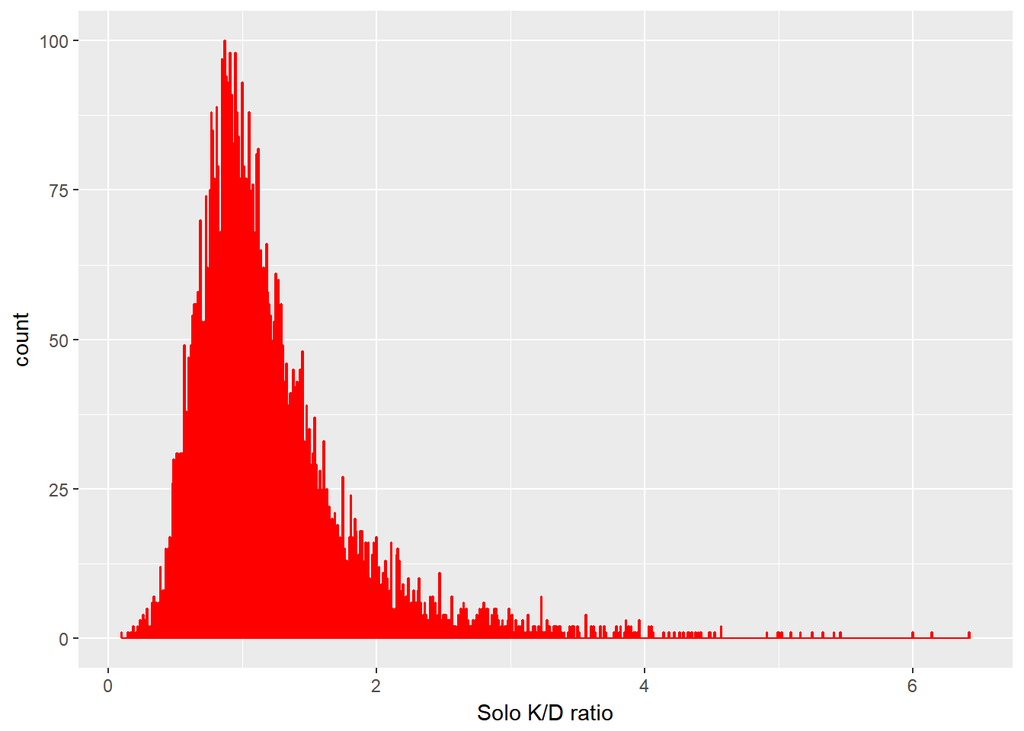

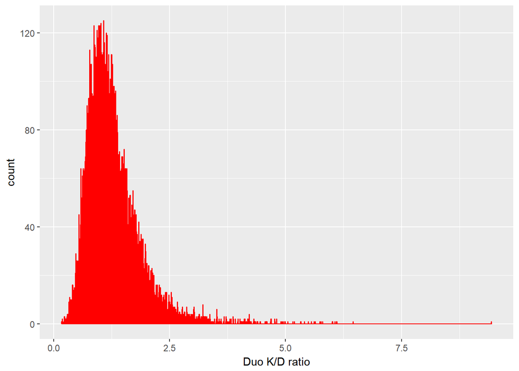

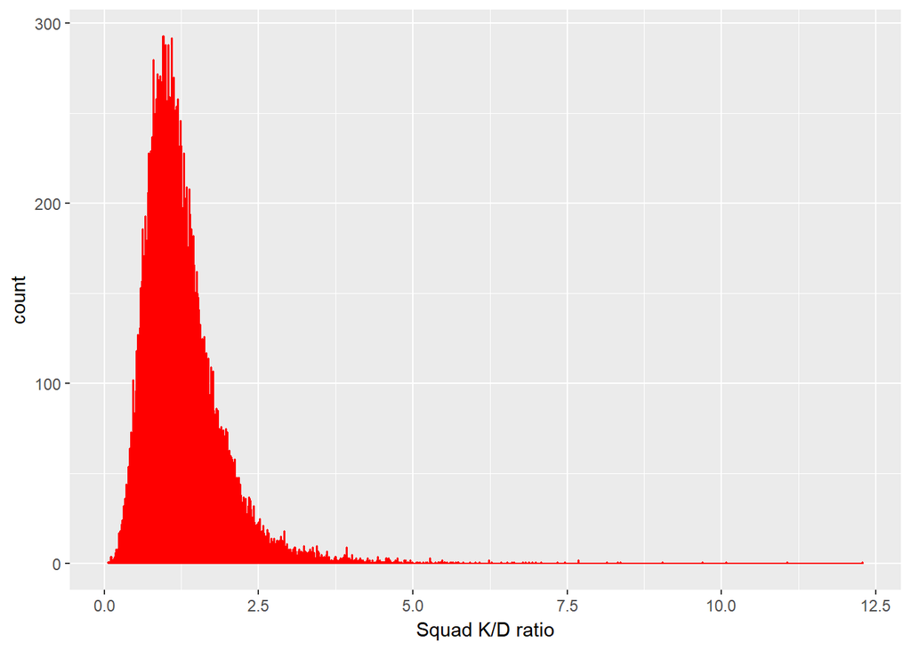

Utilizing the segregated dataset which has been further cut down to players with at least 200 rounds of gameplay experience, we can see that in this set a significant portion of experienced players have a K/D less than a 2.0.

Notes:

- A K/D with approximately a K/D of 4.0 indicates a high degree of skill.
- Those with a K/D of 5.0 seem to be a stable pool of highly skilled players
- Those with a K/D of around 6.0+ seem be the primary outliers to focus on for potential cheating as well since they are well beyond many other players.
- Squad statistics might need a bit of a focus on the further end of the ratios at approximately 6.0+ since the max ratio hits 12.5, well beyond the other datasets.

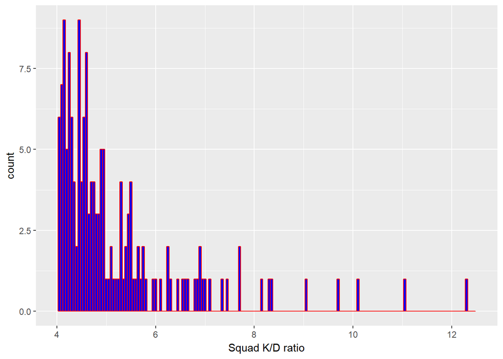

### Kills per Game Count Visualization

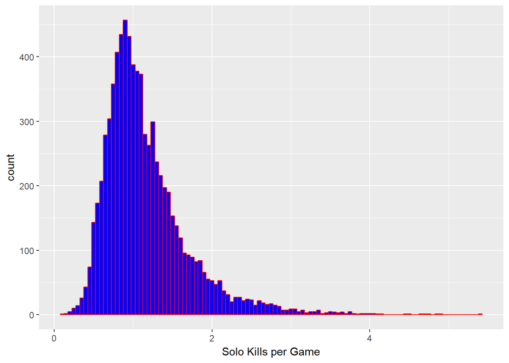

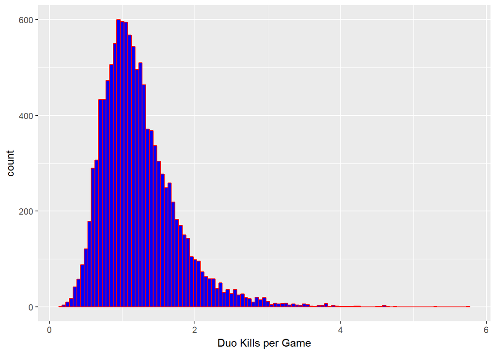

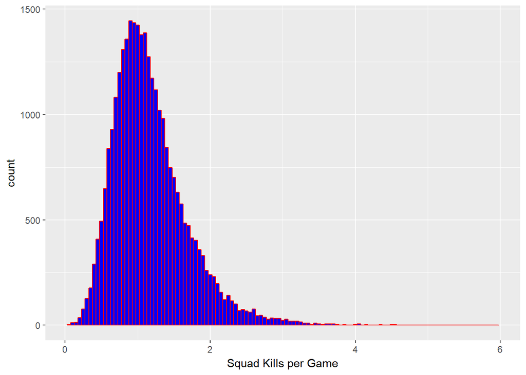

Luckily, the information on kills per game is much more grounded in terms of range.

Notes:

- Players mostly converge around the 1 kill per game area.
- More notable players seem to be around the 3.0+ range for kills per game
  - The population in at that range is where the outliers start to come out in terms of all team compositions.

### Win ratio visualization

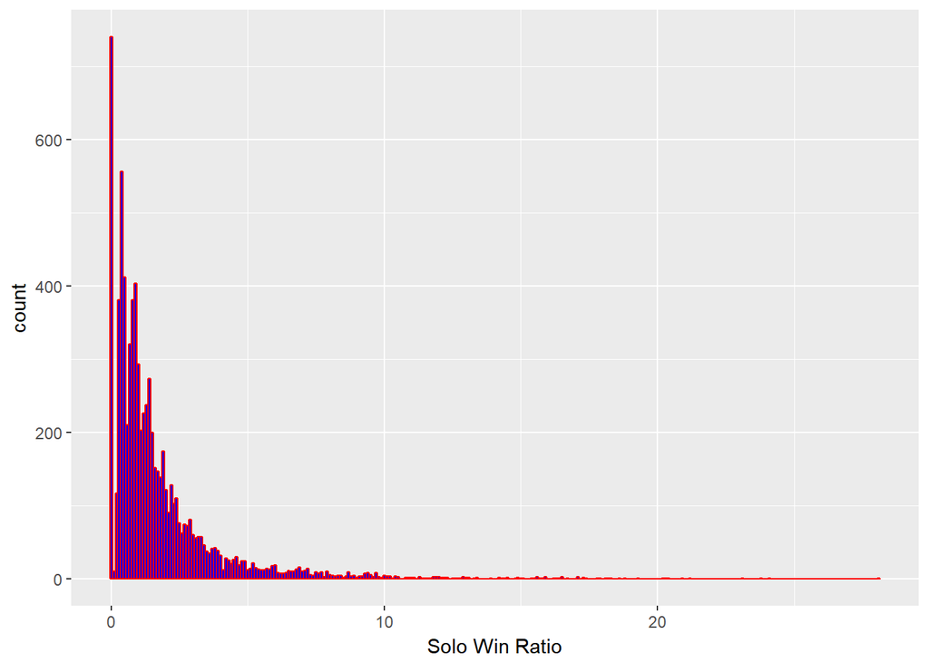

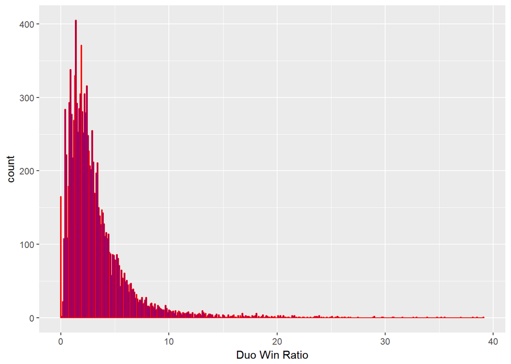

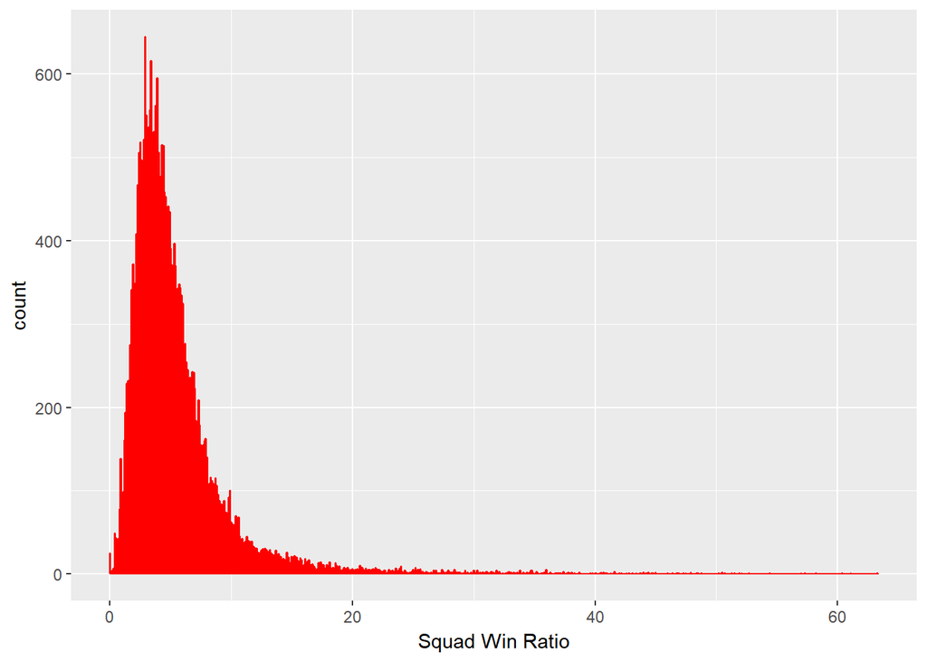

Notes:

- The win ratio average goes up depending on squad composition: Solo<Duo<Squad
  - This makes sense considering that a victory a squad extends to all members, including those that did not make it to the end alive.
- Overall this distribution is to be as expected, since only one squad can win each round, especially where each round can hold approximately 100 players
- Seems like there is data we can not really see at the higher end of the win ratios, so I will try to focus in on those to see the distribution.

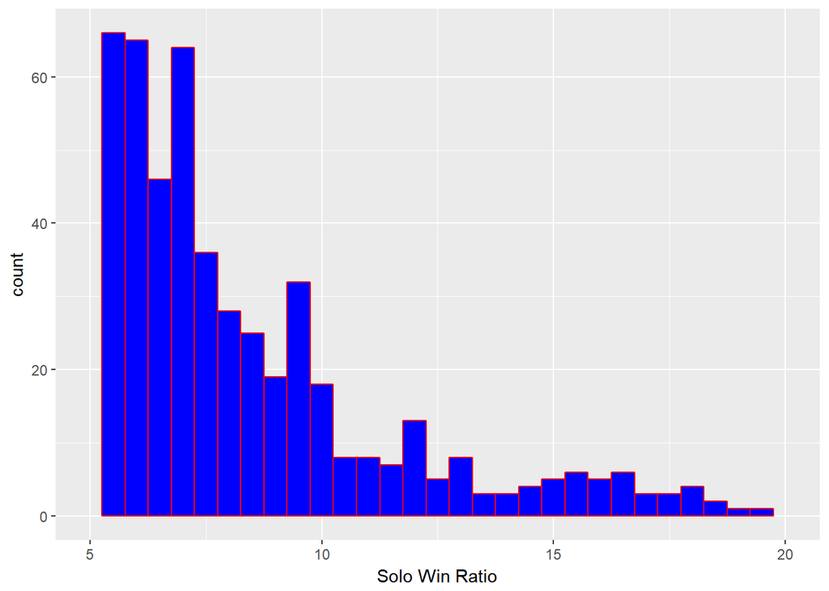

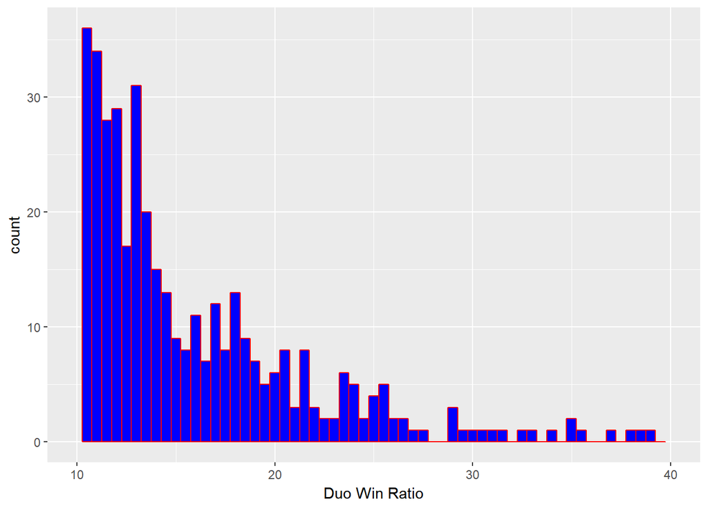

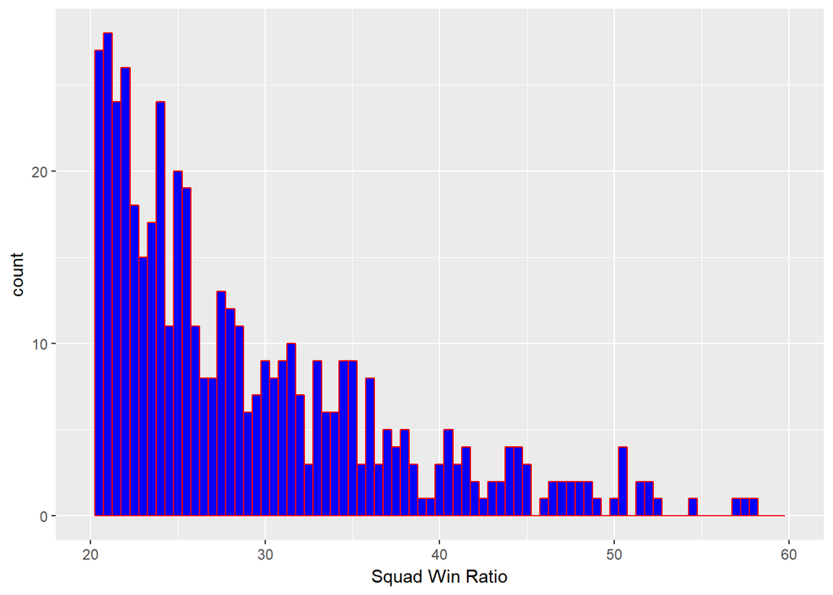

There are still quite a number of players in the higher end ratios, not too surprising considering that there are many players with a win ratio less than 1.0.

### Wins visualization

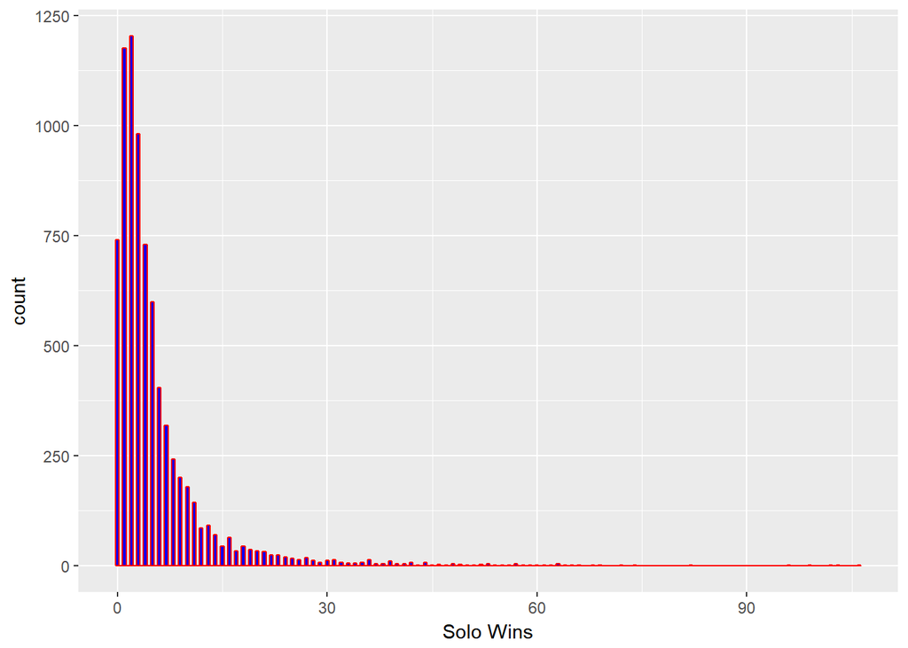

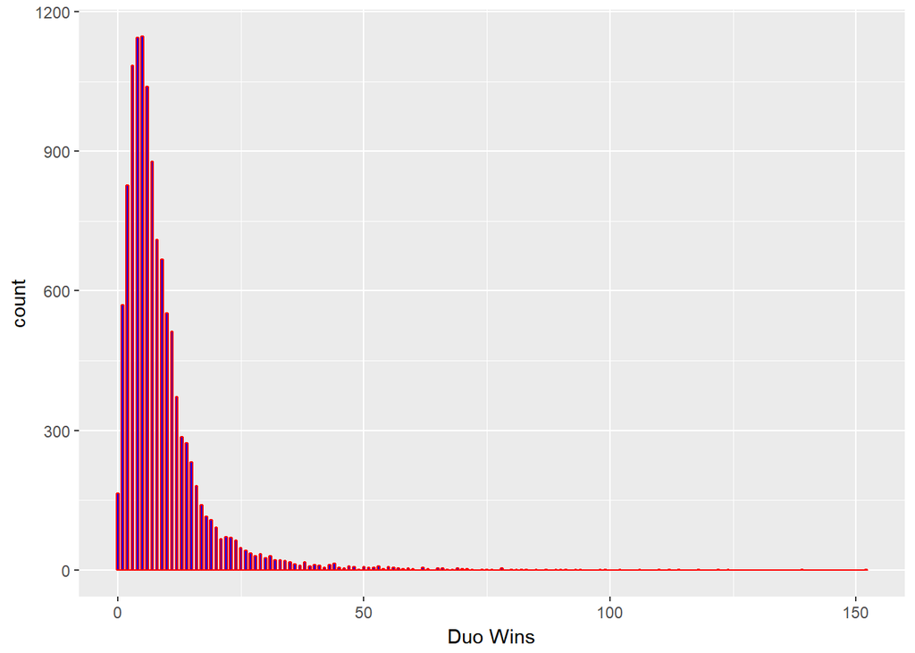

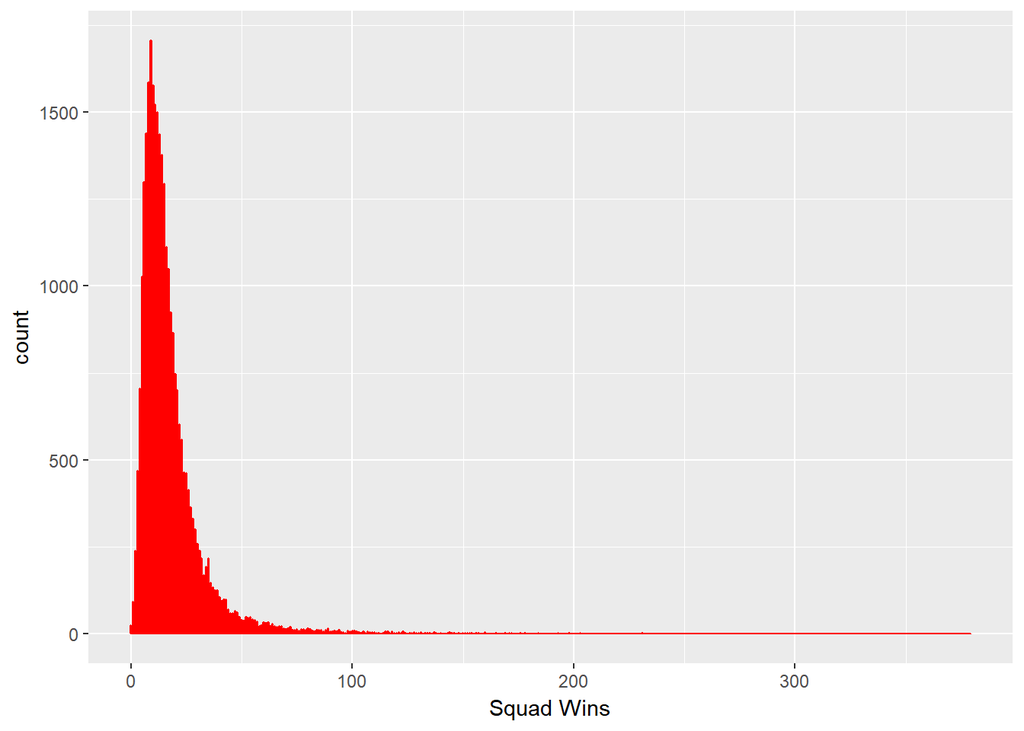

### Rounds Played Visualization

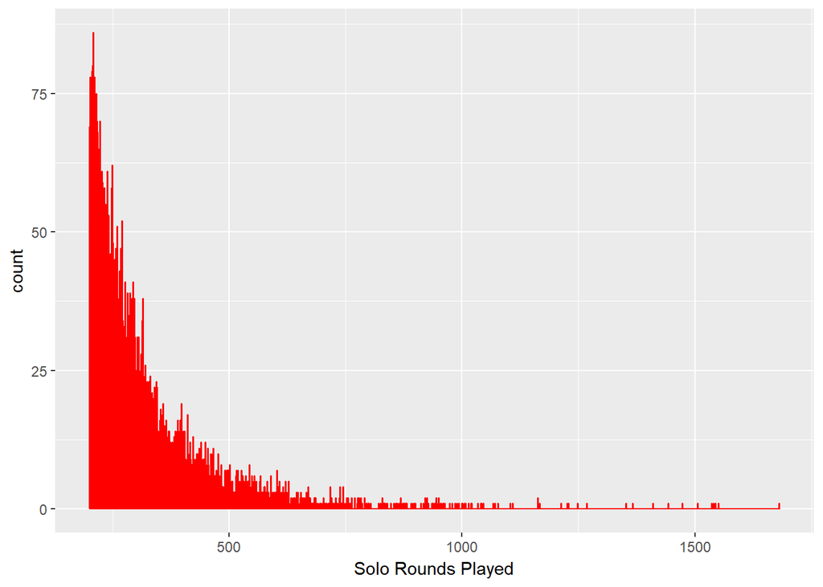

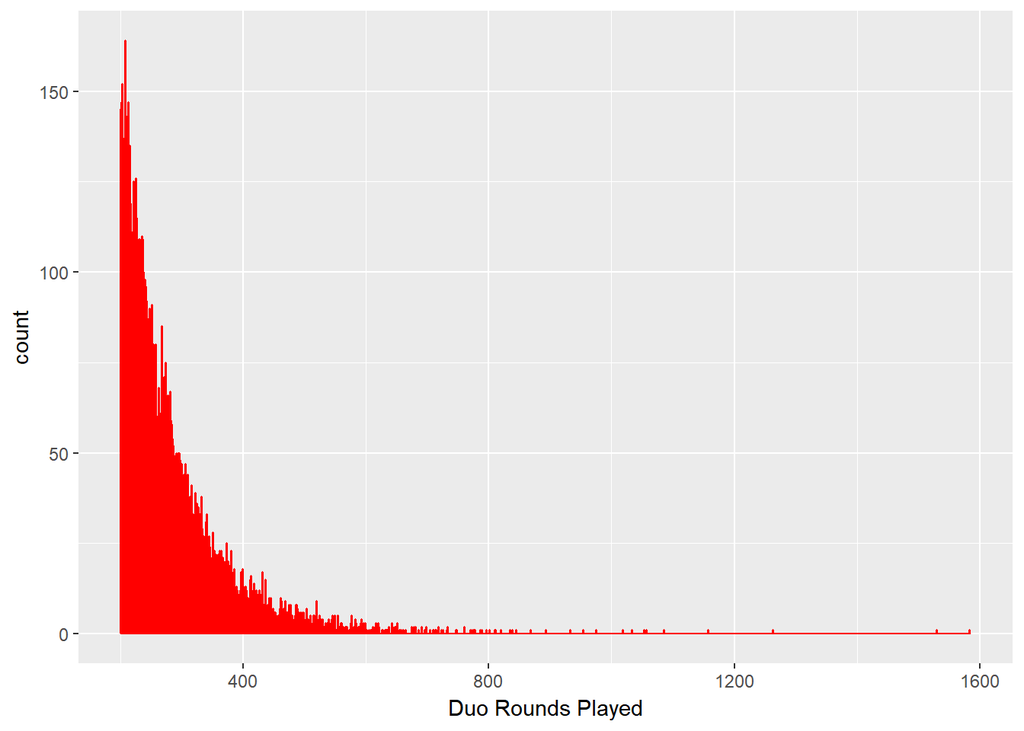

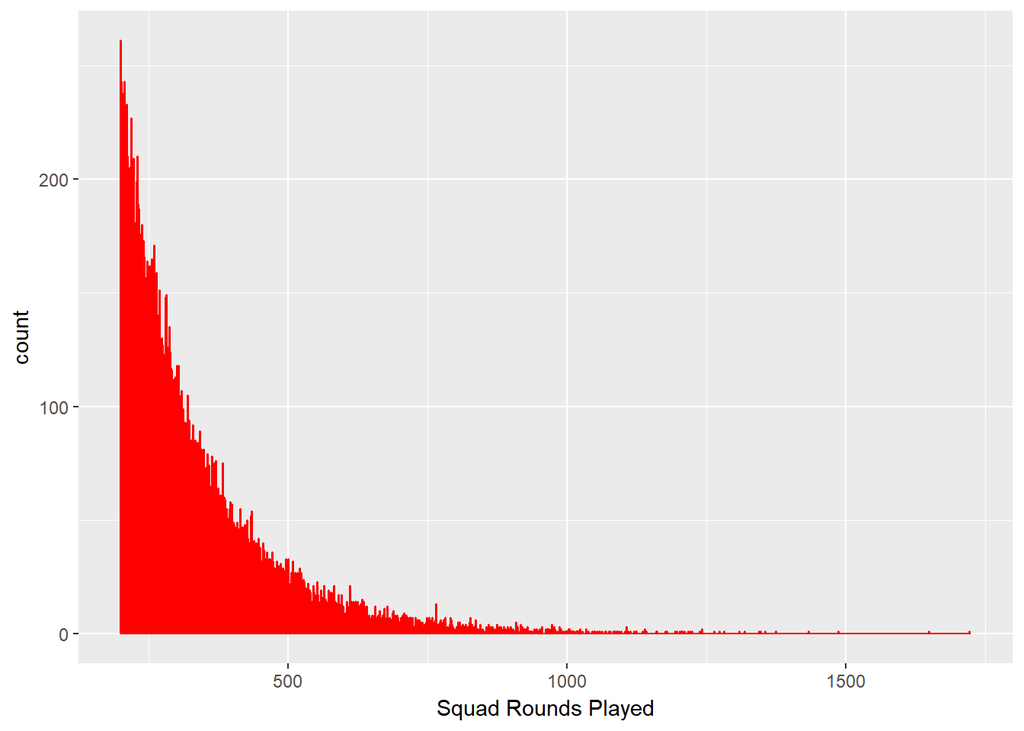

Upon inspecting the win data and the win ratio data, it appears that win ratio is not calculated how I expected it to be. My initial expectations for how win ratio is calculated was by Win/Loss. However it seems apparent throughout the data that this is not the case.

Throughout the datasets this is true: Example from squad statistics: Player: BreakNeck Rounds Played: 642 Squad Wins: 305 Squad Win Ratio: 47.51

## Data Modeling (Machine Learning)

The modeling type I will use for this capstone is the one shown in the curriculum, k-means and clustering.

To ensure that the wssplot function could be utilized on the statistics I have here, I cleaned the data a bit more.

- Changed the player_name column into the row names
- Removed the column player_name

Then I used the wssplot functions defined from the course curriculum to check the number of clusters to use.

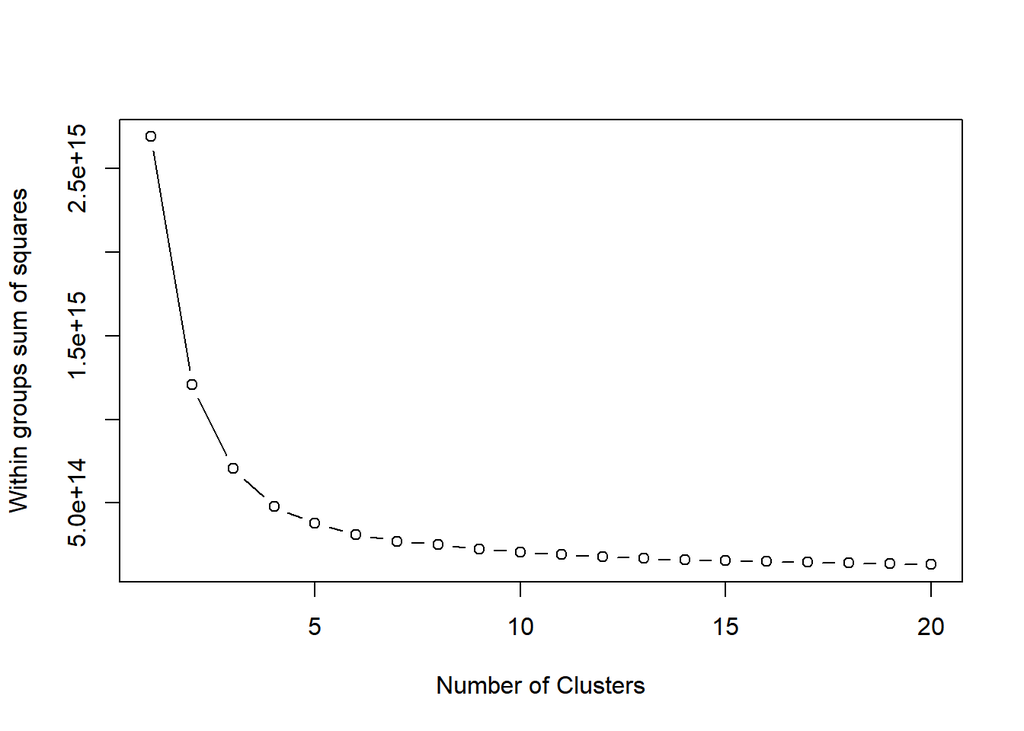

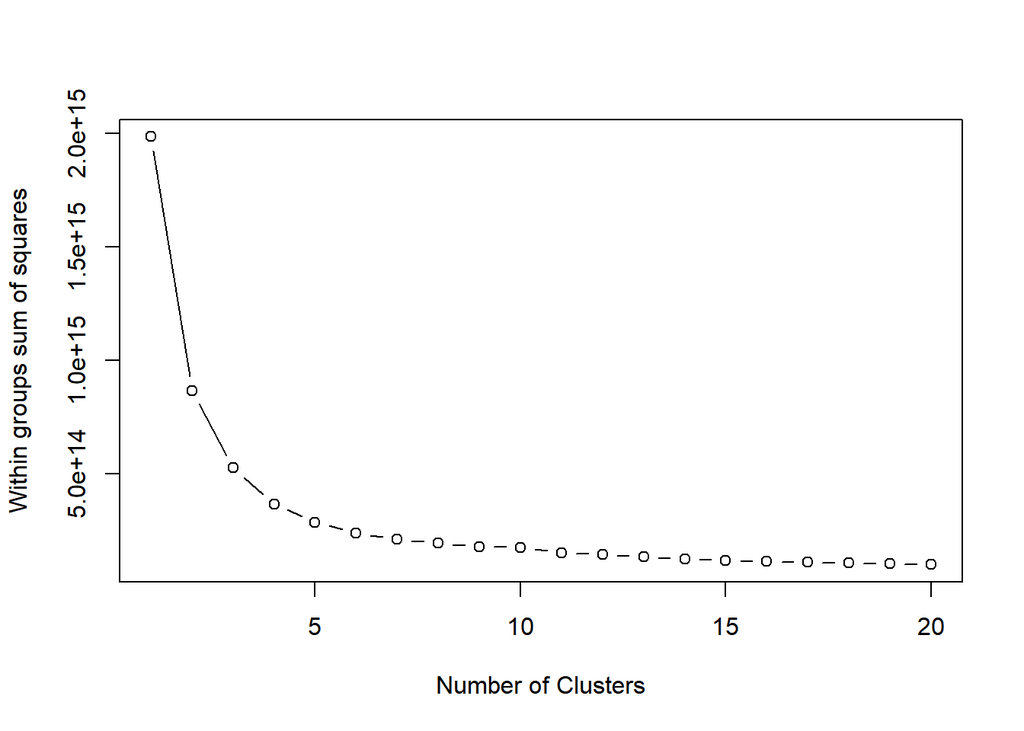

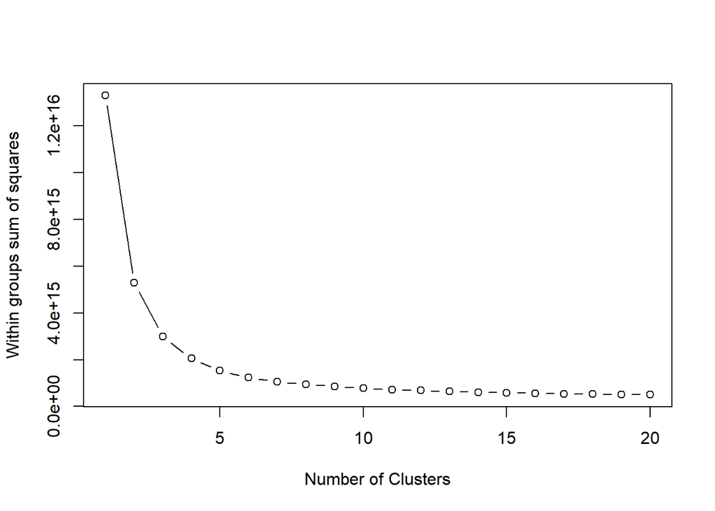

According to the given method for calculating clusters, the number of clusters to utilize is 2 to 3 for all datasets. This makes sense, since the trends in the data for each team composition are approximately the same.

Now applying k-means and plotting the clusters we get:

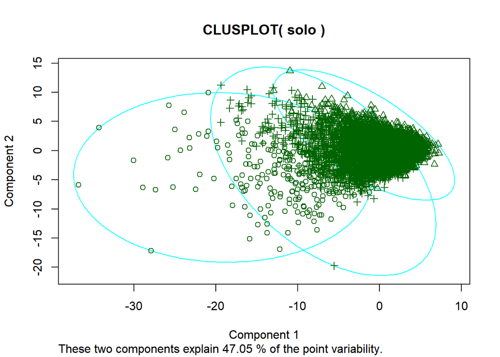

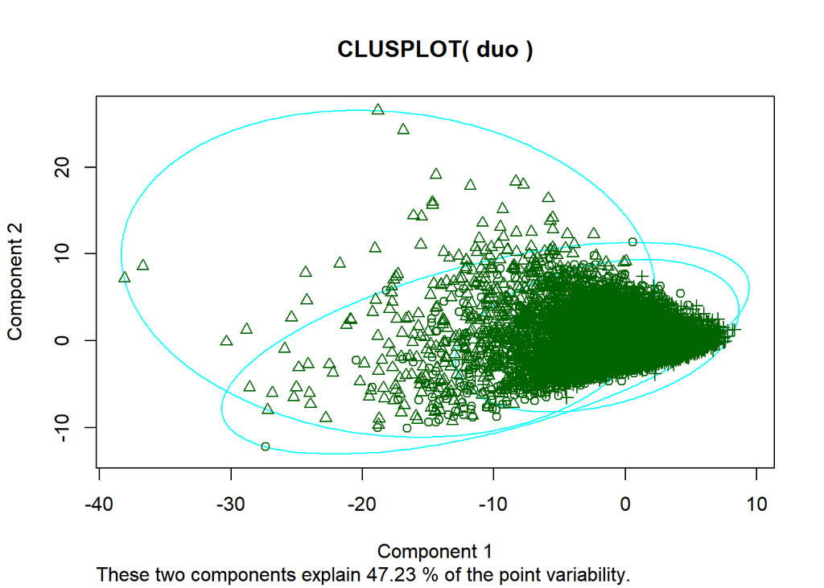

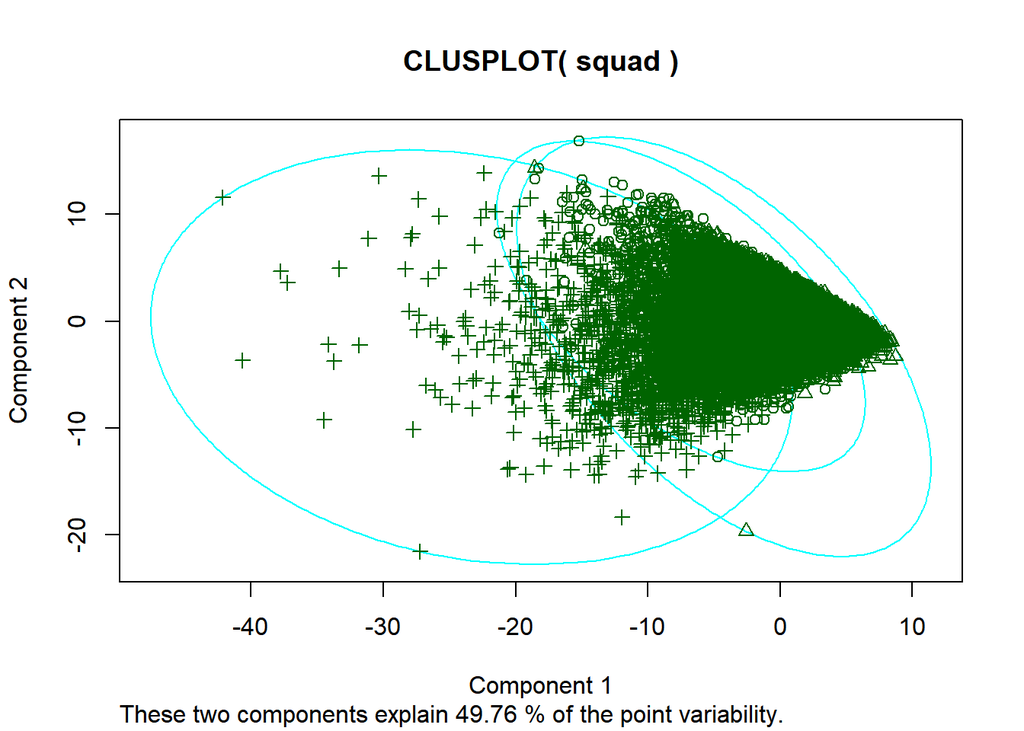

Unfortunately, there appears to be a significant cluster of concentrated values due to many players having quite similar statistics, creating a dense cluster on one end. However, the points I believe we need and would want to learn from are the outliers further out and away from the densely concentrated cluster, so this should be fine in terms of my objective.

As such I identified some sample outliers to analyze:

[figure not shown]

```
## # A tibble: 7 x 5
##   solo_KillDeathRat~ solo_KillsPg solo_WinRatio solo_Wins solo_RoundsPlay~
##                <dbl>        <dbl>         <dbl>     <int>            <int>
## 1              6.42         5.40         15.9          33              207
## 2              6.00         4.87         18.8          68              361
## 3              5.46         4.90         10.2          46              450
## 4              4.91         4.50          8.38        103             1229
## 5              3.50         3.32          5.19         63             1213
## 6              1.32         1.28          3.22         44             1367
## 7              0.540        0.540         0.490         2              407
```

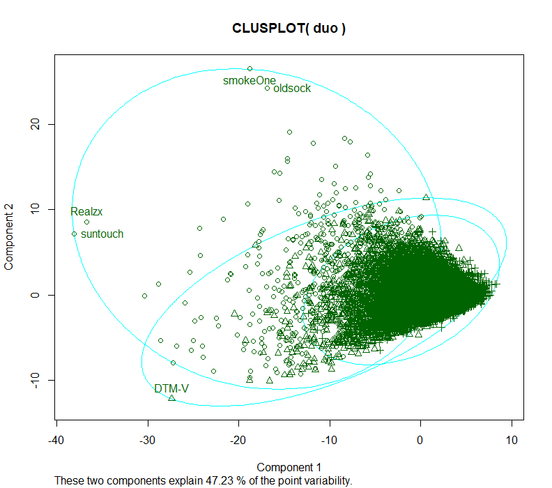

```
## # A tibble: 5 x 5
##   duo_KillDeathRatio duo_KillsPg duo_WinRatio duo_Wins duo_RoundsPlayed
##                <dbl>       <dbl>        <dbl>    <int>            <int>
## 1              0.810       0.800         1.24       19             1531
## 2              0.870       0.860         1.14       18             1584
## 3              4.13        3.39         17.8       124              697
## 4              3.87        3.00         22.5       152              676
## 5              9.44        5.76         39.1        91              233
```

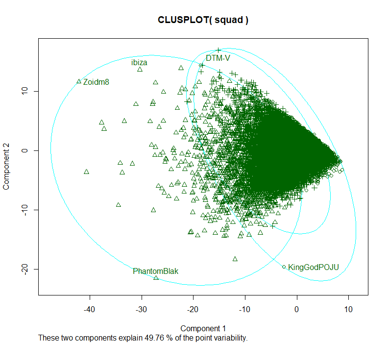

```
## # A tibble: 5 x 5
##   squad_KillDeathRatio squad_KillsPg squad_WinRatio squad_Wins
##                  <dbl>         <dbl>          <dbl>      <int>
## 1                 9.05          4.36          51.9         111
## 2                11.1           4.73          57.3         252
## 3                12.3           5.14          58.2         360
## 4                 1.10          1.04           5.34         92
## 5                 1.04          1.03           1.20          6
## # ... with 1 more variable: squad_RoundsPlayed <int>
```

By looking through the outliers along the cluster edges we see players that play a lot, but also do not do particularly well in the same cluster as those that do much better. It seems that it may be necessary to reduce the amount of columns to create cleaner clusters.

### Focused category clusters

I cleaned the datasets further by reducing the sample size based off of the histogram visualizations. After reducing the size of the datasets I ran wssplot again for cluster numbers.

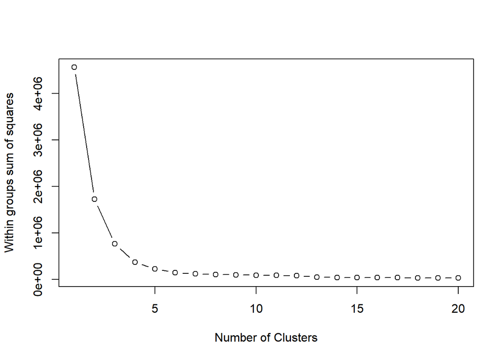

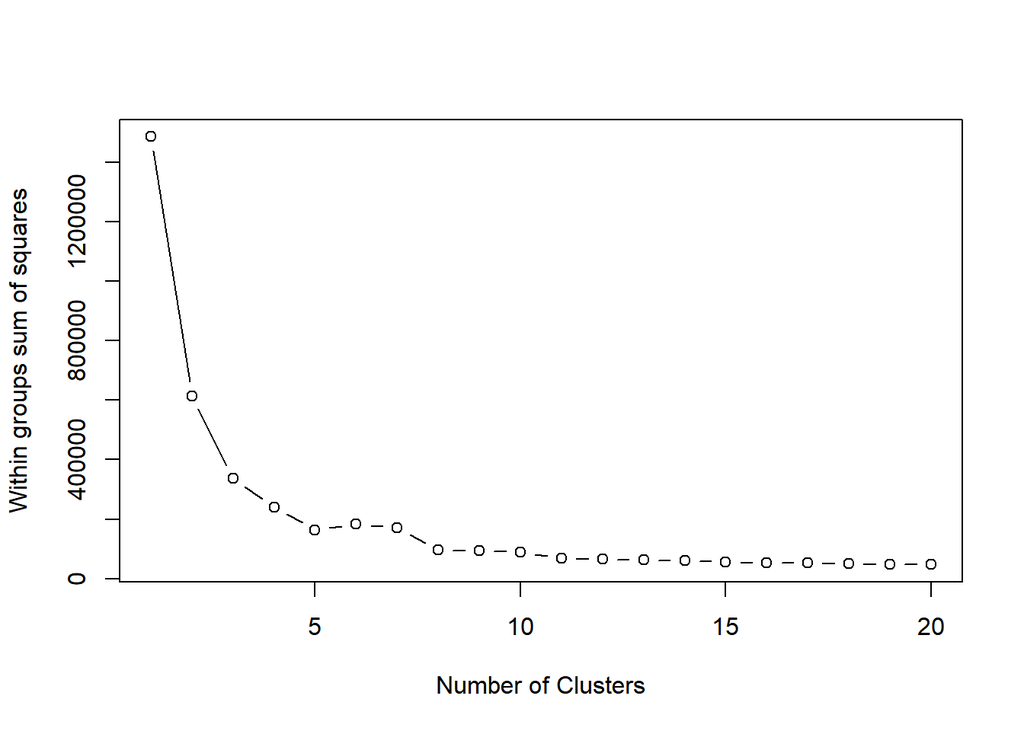

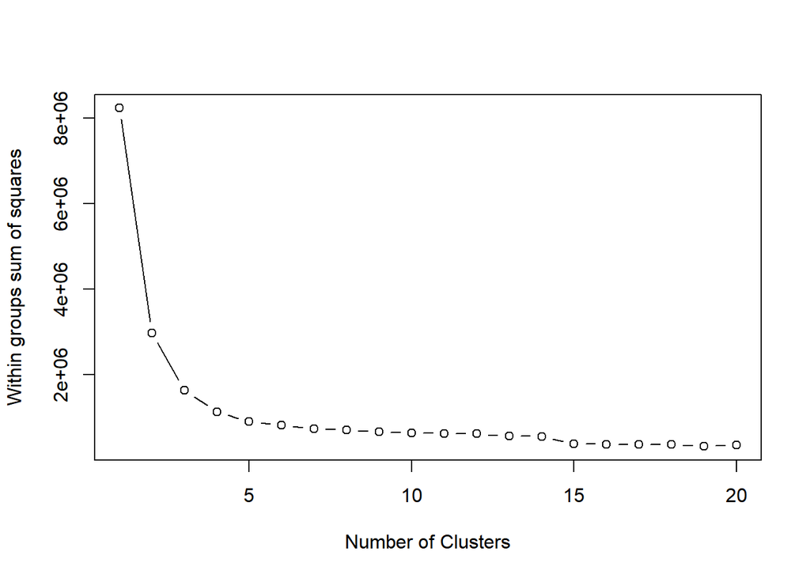